# **Optimizing Computational Efficiency in Gillespie Simulation of Viral Replication**

#### *Michael Sanfilippo - 05/05/2024 - CS-UY 420X*

## **Background & Introduction**

The overall goal of this research project was to develop a stochastic simulation using the Gillespie algorithm to model the viral replication process of negative-sense RNA viruses. During the first research phase, the primary focus was on building a biologically accurate model that could replicate key molecular events in the viral life cycle. This included implementing essential reactions, validating the sequence of molecular events, and ensuring the system behaved realistically over simulated time **[3]**.

The goal of this research phase was to optimize the Gillespie algorithm and gain a deeper understanding of the key driving forces behind the simulation. This process focused on refining the computational efficiency and accuracy of the algorithm, which simulates the stochastic dynamics of molecular interactions. The primary focus was on modeling the replication of negative-sense RNA viruses through a set of seven key molecules.

By the end of the previous research phase, we had successfully developed a stochastic model that accurately represented the viral replication process. The model was capable of simulating a five-hour replication cycle, providing a partial view of viral behavior over extended periods. However, due to computational limitations, the simulation could not run in its entirety, leaving the analysis incomplete.

Through these advancements, we gained critical insights into the algorithm's performance, particularly in terms of reaction rate sensitivity and computational scalability, setting the stage for further optimizations and analyses.

## **Schematic Representation of Negative-Sense RNA Viral Replication**

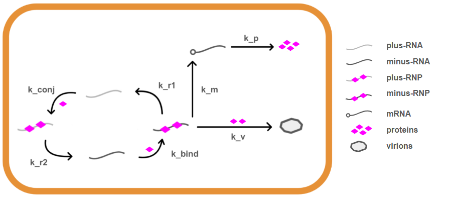

```python
from IPython.display import Image
Image(filename='schematic_model.png')
```

***Figure 0: Schematic Model of Negative-Sense RNA Viral Replication***

Figure 0 shows a schematic representation of negative-sense RNA viral replication. Substrates of the replication process are labeled on the right-hand side of the model, and the production rate symbols of each substrate are indicated. Note that each molecule also has a degradation rate, which is not shown for simplicity.

## **Names of Reactions in the Viral Replication Model**

| **Symbol** | **Description** |
| --- | --- |
| `k_r1` | rate of plus-RNA production |
| `k_r2` | rate of minus-RNA production |
| `k_m` | rate of mRNA production |
| `k_p` | rate of protein production |
| `k_v` | rate of virion production |
| `k_bind` | rate of minus-RNP production |
| `k_conj` | rate of plus-RNP production |
| `d_r1` | degradation rate of minus-RNA |
| `d_r2` | degradation rate of plus-RNA |
| `d_m` | degradation rate of mRNA |
| `d_p` | degradation rate of protein |
| `d_np` | degradation rate of minus-RNP |
| `d_pp` | degradation rate of plus-RNP |
| `d_v` | degradation rate of virions |

***Table 1. Reaction Rates Used in the Stochastic Viral Replication Model***

Note: Reaction rates are not fixed and were adjusted iteratively throughout the development and calibration of the model **[4]**.

```python
pip install numpy matplotlib plotly pandas scipy kaleido
```

```python
import os
import numpy as np
import pandas as pd
import plotly.io as pio
import matplotlib.pyplot as plt
import plotly.graph_objs as go
from scipy.stats import poisson
from scipy.integrate import solve_ivp
import matplotlib.image as mpimg
```

# **7 Molecule Model of Negative-Sense RNA Viral Replication**

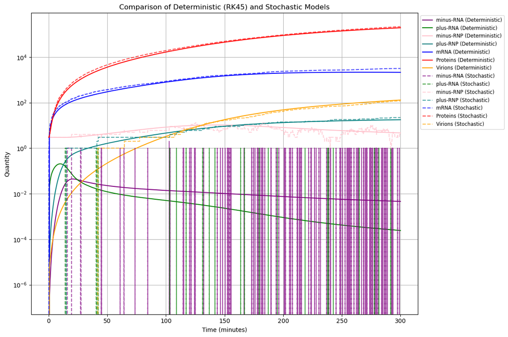

```python
def viral_replication(t, z, k_r1, k_r2, k_m, k_p, k_bind, k_conj, k_v, d_r1, d_r2, d_m, d_p, d_np, d_pp, d_v):
    minus_RNA, plus_RNA, minus_RNP, plus_RNP, mRNA, Proteins, Virions = z
    d_minus_RNA_dt = k_r2 * plus_RNP - d_r1 * minus_RNA - k_bind * minus_RNA * Proteins
    d_plus_RNA_dt = k_r1 * minus_RNP - d_r2 * plus_RNA - k_conj * plus_RNA * Proteins
    d_minus_RNP_dt = k_bind * minus_RNA * Proteins - d_np * minus_RNP - k_v * minus_RNP * Proteins
    d_plus_RNP_dt = k_conj * plus_RNA * Proteins - d_pp * plus_RNP
    d_mRNA_dt = k_m * minus_RNP - d_m * mRNA
    d_Proteins_dt = k_p * mRNA - d_p * Proteins - k_bind * minus_RNA * Proteins - k_conj * plus_RNA * Proteins - k_v * minus_RNP * Proteins
    d_Virions_dt = k_v * minus_RNP * Proteins

    return [
        d_minus_RNA_dt, d_plus_RNA_dt, d_minus_RNP_dt, d_plus_RNP_dt,
        d_mRNA_dt, d_Proteins_dt, d_Virions_dt
    ]

# Reaction rates
REACTION_RATES = {
    'k_r1': 0.01, 'k_r2': 0.05, 'k_m': 2, 'k_p': 0.5, 'k_bind': 0.001,
    'k_conj': 0.001, 'k_v': 1e-6, 'd_r1': 0.001, 'd_r2': 0.001,
    'd_m': 0.005, 'd_p': 1e-4, 'd_np': 0.001, 'd_pp': 0.001, 'd_v': 0
}

# Initial conditions for the deterministic model
initial_conditions = [0, 0, 3, 0, 0, 3, 0]
t_span = (0, 300)
t_eval = np.linspace(0, 300, 500)

# Solve the deterministic model
solution = solve_ivp(
    viral_replication, t_span, initial_conditions,
    args=(REACTION_RATES['k_r1'], REACTION_RATES['k_r2'], REACTION_RATES['k_m'],
          REACTION_RATES['k_p'],  REACTION_RATES['k_bind'], REACTION_RATES['k_conj'],
          REACTION_RATES['k_v'], REACTION_RATES['d_r1'], REACTION_RATES['d_r2'],
          REACTION_RATES['d_m'], REACTION_RATES['d_p'], REACTION_RATES['d_np'],
          REACTION_RATES['d_pp'], REACTION_RATES['d_v']),
    t_eval=t_eval, method='RK45'
)

# Gillespie Simulation for the stochastic model
def gillespie_simulation(initial_state, reaction_rates, time_limit, stoichiometry, dependency_matrix):
    current_time = 0
    state = np.array(list(initial_state.values()))
    history = [(current_time, state.copy())]

    rate_constants = np.array(list(reaction_rates.values()))

    while current_time < time_limit:
        propensities = rate_constants * np.prod(np.power(state[:, np.newaxis], dependency_matrix), axis=0)
        propensity_sum = np.sum(propensities)

        if propensity_sum == 0:
            break

        time_to_next_reaction = -np.log(np.random.rand()) / propensity_sum
        current_time += time_to_next_reaction

        reaction_probabilities = propensities / propensity_sum
        next_reaction = np.random.choice(len(propensities), p=reaction_probabilities)

        state += stoichiometry[:, next_reaction]
        state = np.maximum(state, 0)
        history.append((current_time, state.copy()))

    return history

# Define initial state for stochastic simulation
initial_state = {'minus_RNA': 0, 'plus_RNA': 0, 'minus_RNP': 3, 'plus_RNP': 0, 'mRNA': 0, 'Proteins': 3, 'Virions': 0}
time_limit = 300

# Stoichiometry and dependency matrices
stoichiometry = np.array([
    [0, +1, 0, 0, -1, 0, 0, -1, 0, 0, 0, 0, 0, 0],
    [+1, 0, 0, 0, 0, -1, 0, 0, -1, 0, 0, 0, 0, 0],
    [0, 0, 0, 0, +1, 0, -1, 0, 0, -1, 0, 0, 0, 0],
    [0, 0, 0, 0, 0, +1, 0, 0, 0, 0, -1, 0, 0, 0],
    [0, 0, +1, 0, 0, 0, 0, 0, 0, 0, 0, -1, 0, 0],
    [0, 0, 0, +1, -1, -1, -1, 0, 0, 0, 0, 0, -1, 0],
    [0, 0, 0, 0, 0, 0, +1, 0, 0, 0, 0, 0, 0, -1],
])

dependency_matrix = np.array([
    [0, 0, 0, 0, +1, 0, 0, +1, 0, 0, 0, 0, 0, 0],
    [0, 0, 0, 0, 0, +1, 0, 0, +1, 0, 0, 0, 0, 0],
    [1, 0, +1, 0, 0, 0, +1, 0, 0, +1, 0, 0, 0, 0],
    [0, 1, 0, 0, 0, 0, 0, 0, 0, 0, +1, 0, 0, 0],
    [0, 0, 0, +1, 0, 0, 0, 0, 0, 0, 0, +1, 0, 0],
    [0, 0, 0, 0, +1, +1, +1, 0, 0, 0, 0, 0, +1, 0],
    [0, 0, 0, 0, 0, 0, 0, 0, 0, 0, 0, 0, 0, +1],
])

# Run Gillespie simulation
simulation_history = gillespie_simulation(initial_state, REACTION_RATES, time_limit, stoichiometry, dependency_matrix)
stochastic_times, stochastic_states = zip(*simulation_history)
stochastic_states = np.array(stochastic_states)

# Plot both deterministic and stochastic results
plt.figure(figsize=(12, 8))

# Deterministic results
plt.plot(solution.t, solution.y[0], label='minus-RNA (Deterministic)', color='purple')
plt.plot(solution.t, solution.y[1], label='plus-RNA (Deterministic)', color='green')
plt.plot(solution.t, solution.y[2], label='minus-RNP (Deterministic)', color='pink')
plt.plot(solution.t, solution.y[3], label='plus-RNP (Deterministic)', color='teal')
plt.plot(solution.t, solution.y[4], label='mRNA (Deterministic)', color='blue')
plt.plot(solution.t, solution.y[5], label='Proteins (Deterministic)', color='red')
plt.plot(solution.t, solution.y[6], label='Virions (Deterministic)', color='orange')

# Stochastic results
plt.step(stochastic_times, stochastic_states[:, 0], where='post', linestyle='--', label='minus-RNA (Stochastic)', color='purple', alpha=0.7)
plt.step(stochastic_times, stochastic_states[:, 1], where='post', linestyle='--', label='plus-RNA (Stochastic)', color='green', alpha=0.7)
plt.step(stochastic_times, stochastic_states[:, 2], where='post', linestyle='--', label='minus-RNP (Stochastic)', color='pink', alpha=0.7)
plt.step(stochastic_times, stochastic_states[:, 3], where='post', linestyle='--', label='plus-RNP (Stochastic)', color='teal', alpha=0.7)
plt.step(stochastic_times, stochastic_states[:, 4], where='post', linestyle='--', label='mRNA (Stochastic)', color='blue', alpha=0.7)
plt.step(stochastic_times, stochastic_states[:, 5], where='post', linestyle='--', label='Proteins (Stochastic)', color='red', alpha=0.7)
plt.step(stochastic_times, stochastic_states[:, 6], where='post', linestyle='--', label='Virions (Stochastic)', color='orange', alpha=0.7)

# Formatting the plot
plt.title('Comparison of Deterministic (RK45) and Stochastic Models')
plt.xlabel('Time (minutes)')
plt.ylabel('Quantity')
plt.yscale('log')
plt.legend()
plt.grid()

plt.legend(loc='upper left', bbox_to_anchor=(1, 1), fontsize='small')

plt.tight_layout()
plt.savefig('7_stoch_model.png')
plt.show()
```

***Figure 1: Comparison of 7 Molecule Stochastic and Deterministic Models***

### Moving Forward

The results from the previous period, including the code and graph (figure 1) showing the viral replication dynamics, provided a solid foundation for the next phase of our research. These initial simulations allowed us to identify key areas for optimization, setting the stage for refining the Gillespie algorithm and improving its computational efficiency. With this baseline, we were able to focus on enhancing the simulation’s performance and understanding the factors that drive its behavior.

# **But first, a few changes...**

Before moving forward, parameters were modified to align with our system's time scale. While the values in the reference paper were based on hours, our model uses minutes as the time unit. As a result, all parameters were divided by 60. Additionally, small adjustments were made to fine-tune the final parameter values, ensuring consistency with the model’s requirements **[4]**.

```python
# Reaction rates (per hour)
REACTION_RATES = {
    'k_r1': 1.0, 'k_r2': 10.0, 'k_m': 1e2, 'k_p': 5**2, 'k_bind': 1e-4,
    'k_conj': 1e-4, 'k_v': 1e-6, 'd_r1': 1.0, 'd_r2': 1.0, 'd_m': 0.1,
    'd_p': 1e-4, 'd_np': 0.1, 'd_pp': 0.1, 'd_v': 0
}

# Convert to per minute
REACTION_RATES = {k: v / 60 for k, v in REACTION_RATES.items()}
```

Our focus shifted to identifying bottlnecks in our code and potential ways in which we could optimize computational effciency.

# **Our thought process, though not successful.**

Throughout our optimization efforts, we explored several potential strategies to improve the computational efficiency of the simulation. While each of these approaches seemed promising, none produced the desired results, and some even led to unexpected issues that either broke the simulation or had no effect on efficiency. Below are the four strategies we attempted:

### 1. Compute Propensities Only Once at the Start

**Before:** In the original setup, the propensities were recalculated inside the while loop on every iteration. This was inefficient because it involved recomputing propensities for reactions that hadn’t been affected by the previous reaction, creating unnecessary computational overhead.

```python
propensities = rate_constants * np.prod(np.power(state[:, np.newaxis], dependency_matrix), axis=0)
propensity_sum = np.sum(propensities)
```

**After:** We attempted to compute the propensities once before entering the loop, assuming that the reaction rate wouldn’t depend on the number of molecules.

```python
propensities = rate_constants * np.prod(np.power(state[:, np.newaxis], dependency_matrix), axis=0)
```

**Result**: In the Gillespie algorithm, propensities are dynamic. They change every time a reaction happens, since reactions depend on the current state of the system (i.e., the number of molecules). Therefore, this adjustment had no effect on improving computational efficiency and caused major issues with the simulation.

### 2. Update Only the Propensities for Affected Reactions

**Before:** All propensities were recalculated, regardless of whether the reaction was affected by the most recent update.

**After:** We implemented a method to update only the affected propensities, targeting specific reactions rather than recalculating the entire set of reactions.

```python
affected_reactions = np.where(dependency_matrix[:, next_reaction] > 0)[0]
propensities[affected_reactions] = rate_constants[affected_reactions] * np.prod(
    np.power(state[:, np.newaxis], dependency_matrix[:, affected_reactions]), axis)
```

**Result:** Since reactions that weren’t affected by the most recent event shouldn’t need recalculating, this, in theory, would save computation time by focusing only on the necessary updates. While this approach seemed logical, it did not improve efficiency.

### 3. Optimize Reaction Selection with Inverse Transform Sampling

**Before:** The simulation used np.random.choice() for selecting reactions, which is computationally expensive.

**After:** We replaced np.random.choice() with Inverse Transform Sampling, which uses cumulative sums to select reactions more efficiently.

```python
cumulative_sum = np.cumsum(propensities)
random_val = np.random.rand() * propensity_sum
next_reaction = np.searchsorted(cumulative_sum, random_val)
```

**Result**: This technique is known to be faster in selecting reactions since it avoids the overhead of repeated random sampling. Although it was theoretically more efficient, the performance gains were negligible, and it did not help achieve the desired speed improvements.

### 4. Optimize Time Step Calculation by Pre-generating Random Numbers in Batches

**Before:** Each iteration of the loop generated a new random number using np.random.rand().

**After:** We attempted to batch random number generation to avoid the overhead of calling np.random.rand() in every iteration of the loop.

```python
random_numbers = np.random.rand(10000)  # Precompute 10,000 random values
random_index = 0

while current_time < time_limit:
    if random_index >= len(random_numbers):
        random_numbers = np.random.rand(10000)  # Refill buffer
        random_index = 0

    time_to_next_reaction = -np.log(random_numbers[random_index]) / propensity_sum
    random_index += 1
```

**Result**: Batching random number generation should theoretically reduce the overhead by avoiding multiple function calls and improve cache efficiency. Unfortunately, this approach had no meaningful impact on simulation speed and still resulted in long run times.

#### Conclusion

While each of these optimizations seemed promising in theory, none produced the significant computational speed-ups we were hoping for. Some modifications even caused the simulation to break, highlighting the complex interplay between algorithm changes and system behavior. Despite these challenges, the process provided valuable insights into the limitations of our approach and has set the stage for further investigations into more effective optimizations.

# **Introduction to Numba `@njit` Optimization**

#### **What is `njit` and How Does it Work?**

`njit` (Numba’s "No Python JIT" compiler) is a **just-in-time (JIT) compilation** decorator from the Numba library. It **translates Python functions into optimized machine code** at runtime, significantly speeding up numerical computations **[6]**.

Key benefits of `njit` **[5]**:

- **Avoids Python overhead** by compiling code into machine instructions, reducing function call overhead.
- **Loops and array operations are highly optimized**, making them much faster compared to standard NumPy operations.
- **Removes Python’s dynamic type-checking** by enforcing strict type inference at compile time.
- **Prevents interpreter slowdowns** by eliminating unnecessary memory allocations and type conversions.

To improve the performance of our Gillespie algorithm, we turned to **Numba's `@njit` decorator**. By using `@njit`, we could significantly speed up the core components of our simulation — particularly the loops and mathematical calculations that form the backbone of the Gillespie method.

The `@njit` decorator allowed us to compile our simulation function, **reducing runtime** by leveraging **native machine instructions** instead of Python's interpreted code. This was particularly useful for the parts of the algorithm that involve intensive calculations, such as computing propensities and selecting reactions **[5]**.

By applying `@njit`, we were able to run the simulation much faster, enabling us to simulate longer replication cycles and explore a wider range of parameter values without sacrificing accuracy.

### **Understanding Code**

```python
@njit
def gillespie_simulation(initial_state, reaction_rates, time_limit, stoichiometry, dependency_matrix):
    current_time = 0.0
    state = initial_state.copy()
    step_count = 0
    recorded_steps_count = 0  # Count the recorded steps
    history_times = [current_time]
    history_states = [state.copy()]

    num_reactions = reaction_rates.shape[0]
    num_species = state.shape[0]

    while current_time < time_limit:
        step_count += 1

        # Compute propensities for each reaction
        propensities = np.empty(num_reactions, dtype=np.float32)
        for j in range(num_reactions):
            prod = 1.0
            for i in range(num_species):
                if dependency_matrix[i, j] != 0:
                    prod *= state[i] ** dependency_matrix[i, j]
            propensities[j] = reaction_rates[j] * prod

        total_propensity = 0.0
        for j in range(num_reactions):
            total_propensity += propensities[j]

        if total_propensity == 0.0:
            break

        # Time to next reaction
        r1 = np.random.rand()
        dt = -np.log(r1) / total_propensity
        current_time += dt

        # Determine which reaction occurs
        r2 = np.random.rand() * total_propensity
        cumulative = 0.0
        reaction_index = 0
        for j in range(num_reactions):
            cumulative += propensities[j]
            if cumulative >= r2:
                reaction_index = j
                break

        # Update state according to the chosen reaction's stoichiometry
        for i in range(num_species):
            state[i] += stoichiometry[i, reaction_index]
            if state[i] < 0:
                state[i] = 0.0

        # Record the history
        history_times.append(current_time)
        history_states.append(state.copy())
        recorded_steps_count += 1  # Increment recorded steps counter

    return history_times, history_states, step_count, recorded_steps_count
```

The `@njit` tag above the gillespie simulation function indicates that Numba will **compile the function into machine code**, optimizing the performance of the simulation. In the code, the simulation function was refactored to ensure that all operations within the loop are compatible with Numba’s optimization. Specifically, the use of NumPy arrays for mathematical operations, rather than Python lists or objects, ensures that Numba can efficiently vectorize calculations and handle large datasets. This allows the simulation to run faster and handle more iterations, significantly improving performance for longer simulation runs.

# **NUMBA `@njit` 400 Minute Model**

```python
import numpy as np
import pandas as pd
import matplotlib.pyplot as plt
from numba import njit
import cProfile
import pstats
import time

try:
    import psutil
except ImportError:
    psutil = None

# Reaction rates (per minute)
REACTION_RATES = {
    'k_r1': 1.0, 'k_r2': 10.0, 'k_m': 1e2, 'k_p': 5**2, 'k_bind': 1e-4,
    'k_conj': 1e-4, 'k_v': 1e-6, 'd_r1': 1.0, 'd_r2': 1.0, 'd_m': 0.1,
    'd_p': 1e-4, 'd_np': 0.1, 'd_pp': 0.1, 'd_v': 0
}
# Convert to per minute
REACTION_RATES = {k: v / 60 for k, v in REACTION_RATES.items()}

# Initial quantities of molecules
initial_state = {
    'minus_RNA': 0, 'plus_RNA': 0, 'minus_RNP': 3, 'plus_RNP': 0,
    'mRNA': 0, 'Proteins': 1000, 'Virions': 0
}

# Define species order (this order will be used in arrays)
species_order = ['minus_RNA', 'plus_RNA', 'minus_RNP', 'plus_RNP', 'mRNA', 'Proteins', 'Virions']
initial_state_arr = np.array([initial_state[spec] for spec in species_order], dtype=np.float32)

# Stoichiometry matrix (rows: species, columns: reactions)
stoichiometry = np.array([
    [ 0, +1,  0,  0, -1,  0,  0, -1,  0,  0,  0,  0,  0,  0],
    [+1,  0,  0,  0,  0, -1,  0,  0, -1,  0,  0,  0,  0,  0],
    [ 0,  0,  0,  0, +1,  0, -1,  0,  0, -1,  0,  0,  0,  0],
    [ 0,  0,  0,  0,  0, +1,  0,  0,  0,  0, -1,  0,  0,  0],
    [ 0,  0, +1,  0,  0,  0,  0,  0,  0,  0,  0, -1,  0,  0],
    [ 0,  0,  0, +1, -1, -1, -1,  0,  0,  0,  0,  0, -1,  0],
    [ 0,  0,  0,  0,  0,  0, +1,  0,  0,  0,  0,  0,  0, -1],
], dtype=np.float32)

# Dependency matrix (determines which species affect each reaction's propensity)
dependency_matrix = np.array([
    [0, 0,  0,  0, +1,  0,  0, +1,  0,  0,  0,  0,  0,  0],
    [0, 0,  0,  0,  0, +1,  0,  0, +1,  0,  0,  0,  0,  0],
    [1, 0, +1,  0,  0,  0, +1,  0,  0, +1,  0,  0,  0,  0],
    [0, 1,  0,  0,  0,  0,  0,  0,  0,  0, +1,  0,  0,  0],
    [0, 0,  0, +1,  0,  0,  0,  0,  0,  0,  0, +1,  0,  0],
    [0, 0,  0,  0, +1, +1, +1,  0,  0,  0,  0,  0, +1,  0],
    [0, 0,  0,  0,  0,  0,  0,  0,  0,  0,  0,  0,  0, +1],
], dtype=np.float32)

# Convert reaction rates to an array (assuming the insertion order is the intended reaction order)
reaction_rate_arr = np.array(list(REACTION_RATES.values()), dtype=np.float32)

@njit
def gillespie_simulation(initial_state, reaction_rates, time_limit, stoichiometry, dependency_matrix):
    current_time = 0.0
    state = initial_state.copy()
    step_count = 0
    recorded_steps_count = 0  # Count the recorded steps
    history_times = [current_time]
    history_states = [state.copy()]

    num_reactions = reaction_rates.shape[0]
    num_species = state.shape[0]

    while current_time < time_limit:
        step_count += 1

        # Compute propensities for each reaction
        propensities = np.empty(num_reactions, dtype=np.float32)
        for j in range(num_reactions):
            prod = 1.0
            for i in range(num_species):
                if dependency_matrix[i, j] != 0:
                    prod *= state[i] ** dependency_matrix[i, j]
            propensities[j] = reaction_rates[j] * prod

        total_propensity = 0.0
        for j in range(num_reactions):
            total_propensity += propensities[j]

        if total_propensity == 0.0:
            break

        # Time to next reaction
        r1 = np.random.rand()
        dt = -np.log(r1) / total_propensity
        current_time += dt

        # Determine which reaction occurs
        r2 = np.random.rand() * total_propensity
        cumulative = 0.0
        reaction_index = 0
        for j in range(num_reactions):
            cumulative += propensities[j]
            if cumulative >= r2:
                reaction_index = j
                break

        # Update state according to the chosen reaction's stoichiometry
        for i in range(num_species):
            state[i] += stoichiometry[i, reaction_index]
            if state[i] < 0:
                state[i] = 0.0

        # Record the history
        history_times.append(current_time)
        history_states.append(state.copy())
        recorded_steps_count += 1  # Increment recorded steps counter

    return history_times, history_states, step_count, recorded_steps_count

# Plotting function
def plot_static(history, filename):
    times = history[0]
    history_states = np.array(history[1])
    minus_RNAs = history_states[:, 0]
    plus_RNAs = history_states[:, 1]
    minus_RNPs = history_states[:, 2]
    plus_RNPs = history_states[:, 3]
    mRNAs = history_states[:, 4]
    Proteins = history_states[:, 5]
    Virions = history_states[:, 6]

    plt.figure(figsize=(10, 6))
    plt.plot(times, minus_RNAs, label='minus-RNA', color='purple')
    plt.plot(times, plus_RNAs, label='plus-RNA', color='green')
    plt.plot(times, minus_RNPs, label='minus-RNP', color='pink')
    plt.plot(times, plus_RNPs, label='plus-RNP', color='teal')
    plt.plot(times, mRNAs, label='mRNA', color='blue')
    plt.plot(times, Proteins, label='Proteins', color='red')
    plt.plot(times, Virions, label='Virions', color='orange')

    plt.title('Stochastic Model (Gillespie Simulation with Numba)')
    plt.xlabel('Time (minutes)')
    plt.ylabel('Quantity')
    plt.yscale('log')
    plt.legend()
    plt.grid()
    plt.savefig(filename)
    plt.close()
    print("Static plot saved as '{}'".format(filename))

def main():
    # Run the simulation for a 400-minute time limit
    time_limit = 400.0
    history_times, history_states, total_steps, recorded_steps = gillespie_simulation(initial_state_arr, reaction_rate_arr,
                                                         time_limit, stoichiometry, dependency_matrix)

    # Plot the results
    plot_history = (history_times, history_states)
    plot_static(plot_history, filename="400_njit.png")

    # Print final state as a DataFrame
    final_state = history_states[-1]
    final_state_df = pd.DataFrame({
        'Species': species_order,
        'Quantity': final_state
    })
    print("Final quantities after simulation:")
    print(final_state_df)

if __name__ == "__main__":
    main()
```

```
Static plot saved as '400_njit.png'
Final quantities after simulation:
     Species    Quantity
0  minus_RNA        77.0
1   plus_RNA         4.0
2  minus_RNP      7097.0
3   plus_RNP     12310.0
4       mRNA   1138046.0
5   Proteins  16777216.0
6    Virions    101388.0
```

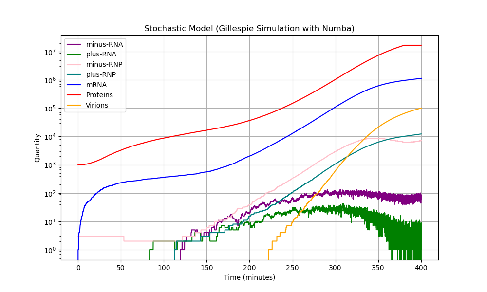

```python
from IPython.display import Image
Image(filename='400_njit.png')
```

***Figure 2: NUMBA `@njit` 400 Minute Stochastic Model***

# **Working towards a full 10 hour simulation...**

Before the history tracking modifications, the simulation was unable to run for a full **600 minutes (10 hours)** due to excessive memory usage, often causing crashes. This was because history was stored at **every step**.

By reducing memory bottlenecks, history tracking was adjusted to record data at fixed intervals (currently every 0.1 minutes), significantly lowering memory usage. Approximately 0.00167% of total simulation steps are recorded when recording every 0.1 minutes in a 600-minute run. This change allowed the simulation to run for the full 600 minutes without crashing, while still capturing essential data for analysis. The core performance improvements from **Numba’s `@njit`** were maintained, and the model ran efficiently without encountering kernel failures.

### **Understanding Code**

```python
current_time = 0.0
state = initial_state.copy()
record_interval = 0.1
last_recorded_time = current_time
history_times = [current_time]
history_states = [state.copy()]
step_count = 0  # Track number of steps
recorded_steps_count = 0  # Track the number of recorded steps

# Record the history only every record_interval minutes
if current_time - last_recorded_time >= record_interval:
    recorded_steps_count += 1  # Increment recorded steps counter
    history_times.append(current_time)
    history_states.append(state.copy())
     last_recorded_time = current_time
```

This code tracks the simulation's progress by recording the state at fixed intervals, defined by `record_interval` (currently set to 0.1 minutes). It checks whether the current time has exceeded the last recorded time by the interval amount, and if so, it updates the history by appending the current time and state. The `recorded_steps_count` is incremented each time a new data point is recorded, and the `last_recorded_time` is updated to the current time.

# **NUMBA `@njit` Full 600-Minute Replication Model**

```python
import numpy as np
import pandas as pd
import matplotlib.pyplot as plt
from numba import njit
import cProfile
import pstats
import time

try:
    import psutil
except ImportError:
    psutil = None

# Reaction rates (per minute)
REACTION_RATES = {
    'k_r1': 1.0, 'k_r2': 10.0, 'k_m': 1e2, 'k_p': 5**2, 'k_bind': 1e-4,
    'k_conj': 1e-4, 'k_v': 1e-6, 'd_r1': 1.0, 'd_r2': 1.0, 'd_m': 0.1,
    'd_p': 1e-4, 'd_np': 0.1, 'd_pp': 0.1, 'd_v': 0
}
# Convert to per minute
REACTION_RATES = {k: v / 60 for k, v in REACTION_RATES.items()}

# Initial quantities of molecules
initial_state = {
    'minus_RNA': 0, 'plus_RNA': 0, 'minus_RNP': 3, 'plus_RNP': 0,
    'mRNA': 0, 'Proteins': 1000, 'Virions': 0
}

# Define species order (this order will be used in arrays)
species_order = ['minus_RNA', 'plus_RNA', 'minus_RNP', 'plus_RNP', 'mRNA', 'Proteins', 'Virions']
initial_state_arr = np.array([initial_state[spec] for spec in species_order], dtype=np.float32)

# Stoichiometry matrix (rows: species, columns: reactions)
stoichiometry = np.array([
    [ 0, +1,  0,  0, -1,  0,  0, -1,  0,  0,  0,  0,  0,  0],
    [+1,  0,  0,  0,  0, -1,  0,  0, -1,  0,  0,  0,  0,  0],
    [ 0,  0,  0,  0, +1,  0, -1,  0,  0, -1,  0,  0,  0,  0],
    [ 0,  0,  0,  0,  0, +1,  0,  0,  0,  0, -1,  0,  0,  0],
    [ 0,  0, +1,  0,  0,  0,  0,  0,  0,  0,  0, -1,  0,  0],
    [ 0,  0,  0, +1, -1, -1, -1,  0,  0,  0,  0,  0, -1,  0],
    [ 0,  0,  0,  0,  0,  0, +1,  0,  0,  0,  0,  0,  0, -1],
], dtype=np.float32)

# Dependency matrix (determines which species affect each reaction's propensity)
dependency_matrix = np.array([
    [0, 0,  0,  0, +1,  0,  0, +1,  0,  0,  0,  0,  0,  0],
    [0, 0,  0,  0,  0, +1,  0,  0, +1,  0,  0,  0,  0,  0],
    [1, 0, +1,  0,  0,  0, +1,  0,  0, +1,  0,  0,  0,  0],
    [0, 1,  0,  0,  0,  0,  0,  0,  0,  0, +1,  0,  0,  0],
    [0, 0,  0, +1,  0,  0,  0,  0,  0,  0,  0, +1,  0,  0],
    [0, 0,  0,  0, +1, +1, +1,  0,  0,  0,  0,  0, +1,  0],
    [0, 0,  0,  0,  0,  0,  0,  0,  0,  0,  0,  0,  0, +1],
], dtype=np.float32)

# Convert reaction rates to an array (assuming the insertion order is the intended reaction order)
reaction_rate_arr = np.array(list(REACTION_RATES.values()), dtype=np.float32)

@njit
def gillespie_simulation(initial_state, reaction_rates, time_limit, stoichiometry, dependency_matrix):
    current_time = 0.0
    state = initial_state.copy()
    record_interval = 0.1
    last_recorded_time = current_time
    history_times = [current_time]
    history_states = [state.copy()]
    step_count = 0  # Track number of steps
    recorded_steps_count = 0  # Track the number of recorded steps

    num_reactions = reaction_rates.shape[0]
    num_species = state.shape[0]

    while current_time < time_limit:
        step_count += 1  # Increment step counter

        # Compute propensities for each reaction
        propensities = np.empty(num_reactions, dtype=np.float32)
        for j in range(num_reactions):
            prod = 1.0
            for i in range(num_species):
                if dependency_matrix[i, j] != 0:
                    prod *= state[i] ** dependency_matrix[i, j]
            propensities[j] = reaction_rates[j] * prod

        total_propensity = 0.0
        for j in range(num_reactions):
            total_propensity += propensities[j]

        if total_propensity == 0.0:
            break

        # Time to next reaction
        r1 = np.random.rand()
        dt = -np.log(r1) / total_propensity
        current_time += dt

        # Determine which reaction occurs
        r2 = np.random.rand() * total_propensity
        cumulative = 0.0
        reaction_index = 0
        for j in range(num_reactions):
            cumulative += propensities[j]
            if cumulative >= r2:
                reaction_index = j
                break

        # Update state according to the chosen reaction's stoichiometry
        for i in range(num_species):
            state[i] += stoichiometry[i, reaction_index]
            if state[i] < 0:
                state[i] = 0.0

        # Record the history only every record_interval minutes
        if current_time - last_recorded_time >= record_interval:
            recorded_steps_count += 1  # Increment recorded steps counter
            history_times.append(current_time)
            history_states.append(state.copy())
            last_recorded_time = current_time

    # Ensure final state is recorded if not already
    if history_times[-1] != current_time:
        history_times.append(current_time)
        history_states.append(state.copy())

    return history_times, history_states, step_count, recorded_steps_count

# Plotting function
def plot_static(history, filename):
    times = history[0]
    history_states = np.array(history[1])
    minus_RNAs = history_states[:, 0]
    plus_RNAs = history_states[:, 1]
    minus_RNPs = history_states[:, 2]
    plus_RNPs = history_states[:, 3]
    mRNAs = history_states[:, 4]
    Proteins = history_states[:, 5]
    Virions = history_states[:, 6]

    plt.figure(figsize=(10, 6))
    plt.plot(times, minus_RNAs, label='minus-RNA', color='purple')
    plt.plot(times, plus_RNAs, label='plus-RNA', color='green')
    plt.plot(times, minus_RNPs, label='minus-RNP', color='pink')
    plt.plot(times, plus_RNPs, label='plus-RNP', color='teal')
    plt.plot(times, mRNAs, label='mRNA', color='blue')
    plt.plot(times, Proteins, label='Proteins', color='red')
    plt.plot(times, Virions, label='Virions', color='orange')

    plt.title('Stochastic Model -- NUMBA with Interval Tracking')
    plt.xlabel('Time (minutes)')
    plt.ylabel('Quantity')
    plt.yscale('log')
    plt.legend()
    plt.grid()
    plt.savefig(filename)
    plt.close()
    print("Static plot saved as '{}'".format(filename))

def main():
    # Run the simulation for a 600-minute time limit
    time_limit = 600.0
    history_times, history_states, total_steps, recorded_steps = gillespie_simulation(initial_state_arr, reaction_rate_arr,
                                                         time_limit, stoichiometry, dependency_matrix)

    # Plot the results
    plot_history = (history_times, history_states)
    plot_static(plot_history, filename="600_njit.png")

    # Print final state as a DataFrame
    final_state = history_states[-1]
    final_state_df = pd.DataFrame({
        'Species': species_order,
        'Quantity': final_state
    })
    print("Final quantities after simulation:")
    print(final_state_df)

if __name__ == "__main__":
    main()
```

```
Static plot saved as '600_njit.png'
Final quantities after simulation:
     Species    Quantity
0  minus_RNA       550.0
1   plus_RNA        31.0
2  minus_RNP     53908.0
3   plus_RNP     94469.0
4       mRNA   8106288.0
5   Proteins  16777216.0
6    Virions   1473924.0
```

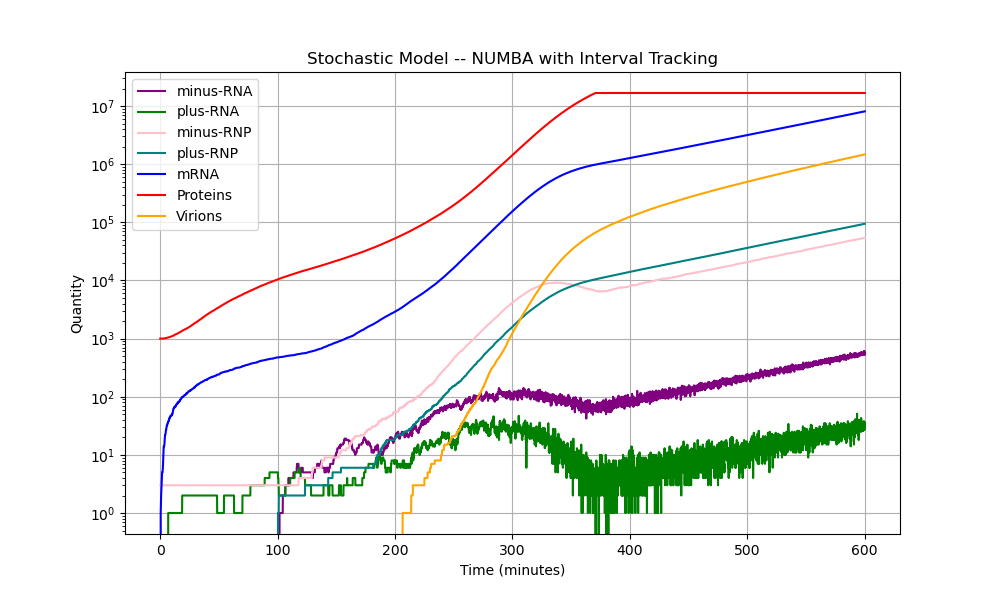

```python
from IPython.display import Image
Image(filename='600_njit.png')
```

***Figure 3: NUMBA `@njit` Full 600 Minute Stochastic Model***

## **Tracking Performance Metrics: Elapsed Time, Steps, Memory Usage, and CPU Usage**

### **NUMBA `njit` Model Conclusion (600 Minutes vs. 400 Minutes)**

To evaluate the effectiveness of our optimization efforts and better understand the resource demands of the simulation, I implemented a system for tracking key performance metrics during the runs. These metrics included elapsed time, total steps, memory usage, and CPU usage. By recording and analyzing these factors, we were able to assess the computational efficiency of each model and compare the performance across different simulation setups.

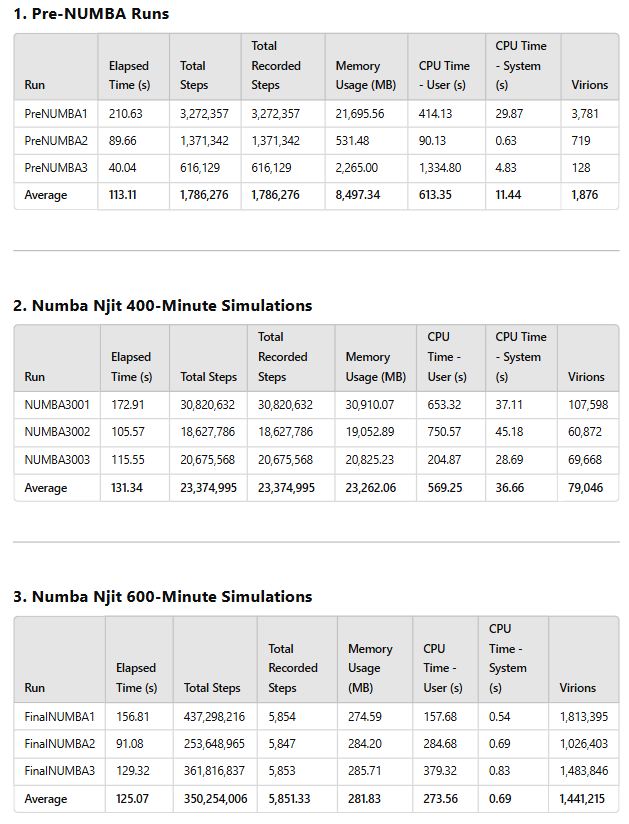

```python
from IPython.display import Image
Image(filename='comparison.png')
```

***Figure 4: Comparison of Model Performance Metrics***

### **Results: Performance Metrics Comparison**

The following table shows the tracked performance metrics for the three models:

1. **Pre-NUMBA Runs**
2. **Numba `@njit` 400-Minute Simulations**
3. **Numba `@njit` 600-Minute Simulations**

These results provide insight into how the different optimization strategies affected **elapsed time**, **memory usage**, **CPU time**, and **virion production**.

**Key Results:**

- **Memory Usage:** The 600-minute simulations used significantly less memory (~8.5GB vs ~23.26GB vs ~0.28GB) despite running for a longer duration, thanks to the optimized history tracking that recorded data at fixed intervals.
- **Number of Reaction Steps:** The 600-minute simulations saw a dramatic increase in the total number of reaction steps (~350M vs ~23M vs ~1.7M). However, the number of recorded steps was much lower in the 600-minute runs due to history being tracked only every 0.1 minutes, which helped solve the excessive memory usage.
- **Elapsed Time:** While the average run time seemed consistent among the three models, each run showed an increase in simulation time, but the elapsed time did not scale proportionally with simulation duration, suggesting optimization.
- **CPU Usage:** CPU usage dropped significantly in the 600-minute runs, indicating **improved computational efficiency** after the optimization efforts.
- **Virion Production:** The final simulation showed **significant increases** in virion production, with higher and more consistent outputs. The variability in the pre-NUMBA model suggests less stability, which may also be due to the shorter simulation time (300 minutes) and the greater potential for variability.

# **A small, yet *IMPORTANT* change...**

In our previous models, we saw uncontrolled growth of virions throughout the entirety of the simulation, regardless of simulation time. We know that this is not biologically accurate. For negative-sense RNA viruses — and most viruses, for that matter — virions are not produced infinitely, and the infected cell will lyse when a certain amount of virions are produced. With this now in mind, we modified our simulation to account for this biological principle.

```python
LYSIS_THRESHOLD = 1e4
lysis_time = None

# Check for lysis condition (if virions exceed threshold)
   if state[6] >= LYSIS_THRESHOLD:
   lysis_time = current_time
   break
```

The code checks if the number of virions exceeds a predefined threshold (`LYSIS_THRESHOLD = 1e4`) — a lysis threshold of 1e4 is standard for negative-sense RNA viruses. If the condition is met, the simulation records the lysis time (`lysis_time = current_time`) and breaks the loop, halting the simulation. This modification ensures the simulation reflects the biological principle that the infected cell will lyse once a certain number of virions are produced, preventing uncontrolled viral growth.

# **FINAL Stochatastic Model (including lysis threshold and future key metric tracking)**

```python
import os
import csv
import numpy as np
import pandas as pd
import matplotlib.pyplot as plt
from numba import njit
import time
from datetime import datetime

# Reaction rates (per hour)
REACTION_RATES = {
    'k_r1': 1.0, 'k_r2': 10.0, 'k_m': 1e2, 'k_p': 5**2, 'k_bind': 1e-4,
    'k_conj': 1e-4, 'k_v': 1e-6, 'd_r1': 1.0, 'd_r2': 1.0, 'd_m': 0.1,
    'd_p': 1e-4, 'd_np': 0.1, 'd_pp': 0.1, 'd_v': 0
}

# Convert to per minute
REACTION_RATES = {k: v / 60 for k, v in REACTION_RATES.items()}

# Initial quantities of molecules
initial_state = {
    'minus_RNA': 0, 'plus_RNA': 0, 'minus_RNP': 3, 'plus_RNP': 0,
    'mRNA': 0, 'Proteins': 1000, 'Virions': 0
}

# Define species order (this order will be used in arrays)
species_order = ['minus_RNA', 'plus_RNA', 'minus_RNP', 'plus_RNP', 'mRNA', 'Proteins', 'Virions']
initial_state_arr = np.array([initial_state[spec] for spec in species_order], dtype=np.float32)

# Stoichiometry matrix (rows: species, columns: reactions)
stoichiometry = np.array([
    [ 0, +1,  0,  0, -1,  0,  0, -1,  0,  0,  0,  0,  0,  0],
    [+1,  0,  0,  0,  0, -1,  0,  0, -1,  0,  0,  0,  0,  0],
    [ 0,  0,  0,  0, +1,  0, -1,  0,  0, -1,  0,  0,  0,  0],
    [ 0,  0,  0,  0,  0, +1,  0,  0,  0,  0, -1,  0,  0,  0],
    [ 0,  0, +1,  0,  0,  0,  0,  0,  0,  0,  0, -1,  0,  0],
    [ 0,  0,  0, +1, -1, -1, -1,  0,  0,  0,  0,  0, -1,  0],
    [ 0,  0,  0,  0,  0,  0, +1,  0,  0,  0,  0,  0,  0, -1],
], dtype=np.float32)

# Dependency matrix (determines which species affect each reaction's propensity)
dependency_matrix = np.array([
    [0, 0,  0,  0, +1,  0,  0, +1,  0,  0,  0,  0,  0,  0],
    [0, 0,  0,  0,  0, +1,  0,  0, +1,  0,  0,  0,  0,  0],
    [1, 0, +1,  0,  0,  0, +1,  0,  0, +1,  0,  0,  0,  0],
    [0, 1,  0,  0,  0,  0,  0,  0,  0,  0, +1,  0,  0,  0],
    [0, 0,  0, +1,  0,  0,  0,  0,  0,  0,  0, +1,  0,  0],
    [0, 0,  0,  0, +1, +1, +1,  0,  0,  0,  0,  0, +1,  0],
    [0, 0,  0,  0,  0,  0,  0,  0,  0,  0,  0,  0,  0, +1],
], dtype=np.float32)

# Convert reaction rates to an array (assuming the insertion order is the intended reaction order)
reaction_rate_arr = np.array(list(REACTION_RATES.values()), dtype=np.float32)

# Add a Lysis Threshold -- Cell lyse when certain amount of virions are produced
LYSIS_THRESHOLD = 1e4

@njit
def gillespie_simulation(initial_state, reaction_rates, time_limit, stoichiometry, dependency_matrix):
    current_time = 0.0
    state = initial_state.copy()
    record_interval = 1 # Record every minute
    last_recorded_time = current_time
    history_times = [current_time]
    history_states = [state.copy()]
    step_count = 0  # Track number of steps
    recorded_steps_count = 0  # Track the number of recorded steps
    lysis_time = None
    time_to_first_virion = None

    num_reactions = reaction_rates.shape[0]
    num_species = state.shape[0]

    while current_time < time_limit:
        step_count += 1  # Increment step counter

        # Compute propensities for each reaction
        propensities = np.empty(num_reactions, dtype=np.float32)
        for j in range(num_reactions):
            prod = 1.0
            for i in range(num_species):
                if dependency_matrix[i, j] != 0:
                    prod *= state[i] ** dependency_matrix[i, j]
            propensities[j] = reaction_rates[j] * prod

        total_propensity = 0.0
        for j in range(num_reactions):
            total_propensity += propensities[j]

        if total_propensity == 0.0:
            break

        # Time to next reaction
        r1 = np.random.rand()
        dt = -np.log(r1) / total_propensity
        current_time += dt

        # Determine which reaction occurs
        r2 = np.random.rand() * total_propensity
        cumulative = 0.0
        reaction_index = 0
        for j in range(num_reactions):
            cumulative += propensities[j]
            if cumulative >= r2:
                reaction_index = j
                break

        # Update state according to the chosen reaction's stoichiometry
        for i in range(num_species):
            state[i] += stoichiometry[i, reaction_index]
            if state[i] < 0:
                state[i] = 0.0

        # Check for lysis condition (if virions exceed threshold)
        if state[6] >= LYSIS_THRESHOLD:  # Virions are at index 6
            lysis_time = current_time
            break


        # Check for time to first virion
        if state[6] > 0 and time_to_first_virion is None:
            time_to_first_virion = current_time

        # Record the history only every record_interval minutes
        if current_time - last_recorded_time >= record_interval:
            recorded_steps_count += 1  # Increment recorded steps counter
            history_times.append(current_time)
            history_states.append(state.copy())
            last_recorded_time = current_time

    # Ensure final state is recorded if not already
    if history_times[-1] != current_time:
        history_times.append(current_time)
        history_states.append(state.copy())

    return history_times, history_states, step_count, recorded_steps_count, lysis_time, time_to_first_virion

# Plotting function
def plot_static(history, filename):
    times = history[0]
    history_states = np.array(history[1])
    minus_RNAs = history_states[:, 0]
    plus_RNAs = history_states[:, 1]
    minus_RNPs = history_states[:, 2]
    plus_RNPs = history_states[:, 3]
    mRNAs = history_states[:, 4]
    Proteins = history_states[:, 5]
    Virions = history_states[:, 6]

    plt.figure(figsize=(10, 6))
    plt.plot(times, minus_RNAs, label='minus-RNA', color='purple')
    plt.plot(times, plus_RNAs, label='plus-RNA', color='green')
    plt.plot(times, minus_RNPs, label='minus-RNP', color='pink')
    plt.plot(times, plus_RNPs, label='plus-RNP', color='teal')
    plt.plot(times, mRNAs, label='mRNA', color='blue')
    plt.plot(times, Proteins, label='Proteins', color='red')
    plt.plot(times, Virions, label='Virions', color='orange')

    plt.title('Stochatsic Model of Negative-Semse RNA Viral Replication')
    plt.xlabel('Time (minutes)')
    plt.ylabel('Quantity')
    plt.yscale('log')
    plt.legend()
    plt.grid()
    plt.savefig(filename)
    plt.close()
    print("Static plot saved as '{}'".format(filename))

def main():

    history_times, history_states, total_steps, recorded_steps, lysis_time, time_to_first_virion = gillespie_simulation(
        initial_state_arr, reaction_rate_arr, time_limit=600,
        stoichiometry=stoichiometry, dependency_matrix=dependency_matrix
    )

    # Plot the results
    plot_history = (history_times, history_states)
    plot_static(plot_history, filename="gillespie_final.png")

     # Print final state as a DataFrame
    final_state = history_states[-1]
    final_state_df = pd.DataFrame({
        'Species': species_order,
        'Quantity': final_state
    })
    print("Final quantities after simulation:")
    print(final_state_df)
    print ("\n")

    # Extract key metrics
    final_virions = history_states[-1][6]
    sim_time = history_times[-1]
    virion_rate = final_virions / sim_time if sim_time > 0 else 0

    # Print out the metrics
    print(f"Simulation Time (min): {sim_time:.3f}")
    print(f"Final Virions: {final_virions:.3f}")
    print(f"Virion Production Rate (per min): {virion_rate:.3f}")
    print(f"Lysis Time (min): {round(lysis_time, 3) if lysis_time is not None else 'No Lysis'}")
    print(f"Time to First Virion (min): {round(time_to_first_virion, 3) if time_to_first_virion is not None else 'No Virions'}")

if __name__ == "__main__":
    main()
```

```
Static plot saved as 'gillespie_final.png'
Final quantities after simulation:
     Species   Quantity
0  minus_RNA      108.0
1   plus_RNA       19.0
2  minus_RNP     8347.0
3   plus_RNP     4513.0
4       mRNA   440747.0
5   Proteins  4564684.0
6    Virions    10000.0


Simulation Time (min): 320.837
Final Virions: 10000.000
Virion Production Rate (per min): 31.168
Lysis Time (min): 320.837
Time to First Virion (min): 220.06
```

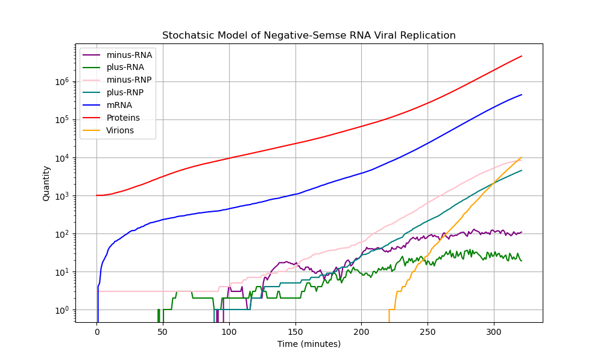

```python
from IPython.display import Image
Image(filename='gillespie_final.png')
```

***Figure 5: Final Stochatsic Model of Negative-Semse RNA Viral Replication***

The above model is the final stochastic model, which includes the lysis threshold implementation as well as the recording of key metrics (introduced in the next section). In the following section, the script that is run each time for each magnitude is the same script documented above.

# **Parameter Testing: Evaluating the Impact of Reaction Rate Modifications**

Following the optimization of memory management and computational efficiency, we next focused on parameter testing to assess how variations in reaction rates would affect the simulation's outcome. This involved adjusting the reaction rates for key parameters and observing the effects on **virion production**, **time to first virion**, and **lysis time**. To do this, we modified each reaction rate, testing them at five different magnitudes of their set reaction rate, ranging from **1.0e-02 to 1.0e+02**. For each reaction rate and magnitude, we ran the simulation **5 times**, taking the average of key metrics from all five runs to ensure the results were reliable and consistent (accounting for stochastic variability). This approach allowed us to systematically evaluate how each parameter influenced the overall dynamics of the simulation.

### **Understanding Code**

```python
for reaction_rate_key in REACTION_RATES.keys():
        print(f"\n--- Running tests for {reaction_rate_key} ---")

        initial_value = REACTION_RATES[reaction_rate_key]
        testing_range = np.logspace(np.log10(0.01), np.log10(100), num=5)

        for factor in testing_range:
            # print(f"Testing {reaction_rate_key} with factor {factor:.1e}...")

            run_results = []

            for i in range(5):  # 10 iterations for stochastic averaging
                modified_rates = REACTION_RATES.copy()
                modified_rates[reaction_rate_key] = initial_value * factor
                reaction_rate_arr = np.array(list(modified_rates.values()), dtype=np.float32)

                history_times, history_states, total_steps, recorded_steps, lysis_time, time_to_first_virion = gillespie_simulation(
                    initial_state_arr, reaction_rate_arr, time_limit=600,
                    stoichiometry=stoichiometry, dependency_matrix=dependency_matrix
                )

                final_virions = history_states[-1][6]
                sim_time = history_times[-1]
                virion_rate = final_virions / sim_time if sim_time > 0 else 0

                run_results.append({
                    "Simulation Time": sim_time,
                    "Final Virions": final_virions,
                    "Virion Production Rate": virion_rate,
                    "Lysis Time": lysis_time if lysis_time is not None else np.nan,
                    "Time to First Virion": time_to_first_virion if time_to_first_virion is not None else np.nan
                })
```

The code runs simulations for each reaction rate parameter by modifying its value across a range of factors, from 10^-2 to 10^2, and testing each factor 5 times for reliability. It then records key metrics such as final virions, simulation time, virion production rate, and lysis time. The results of each test are averaged and stored to assess the impact of reaction rate variations on the simulation's outcome.

```python
import os
import csv
import numpy as np
import pandas as pd
import matplotlib.pyplot as plt
from numba import njit
import time
from datetime import datetime

# Reaction rates (per hour)
REACTION_RATES = {
    'k_r1': 1.0, 'k_r2': 10.0, 'k_m': 1e2, 'k_p': 5**2, 'k_bind': 1e-4,
    'k_conj': 1e-4, 'k_v': 1e-6, 'd_r1': 1.0, 'd_r2': 1.0, 'd_m': 0.1,
    'd_p': 1e-4, 'd_np': 0.1, 'd_pp': 0.1, 'd_v': 0
}

# Convert to per minute
REACTION_RATES = {k: v / 60 for k, v in REACTION_RATES.items()}

# Initial quantities of molecules
initial_state = {
    'minus_RNA': 0, 'plus_RNA': 0, 'minus_RNP': 3, 'plus_RNP': 0,
    'mRNA': 0, 'Proteins': 1000, 'Virions': 0
}

# Define species order (this order will be used in arrays)
species_order = ['minus_RNA', 'plus_RNA', 'minus_RNP', 'plus_RNP', 'mRNA', 'Proteins', 'Virions']
initial_state_arr = np.array([initial_state[spec] for spec in species_order], dtype=np.float32)

# Stoichiometry matrix (rows: species, columns: reactions)
stoichiometry = np.array([
    [ 0, +1,  0,  0, -1,  0,  0, -1,  0,  0,  0,  0,  0,  0],
    [+1,  0,  0,  0,  0, -1,  0,  0, -1,  0,  0,  0,  0,  0],
    [ 0,  0,  0,  0, +1,  0, -1,  0,  0, -1,  0,  0,  0,  0],
    [ 0,  0,  0,  0,  0, +1,  0,  0,  0,  0, -1,  0,  0,  0],
    [ 0,  0, +1,  0,  0,  0,  0,  0,  0,  0,  0, -1,  0,  0],
    [ 0,  0,  0, +1, -1, -1, -1,  0,  0,  0,  0,  0, -1,  0],
    [ 0,  0,  0,  0,  0,  0, +1,  0,  0,  0,  0,  0,  0, -1],
], dtype=np.float32)

# Dependency matrix (determines which species affect each reaction's propensity)
dependency_matrix = np.array([
    [0, 0,  0,  0, +1,  0,  0, +1,  0,  0,  0,  0,  0,  0],
    [0, 0,  0,  0,  0, +1,  0,  0, +1,  0,  0,  0,  0,  0],
    [1, 0, +1,  0,  0,  0, +1,  0,  0, +1,  0,  0,  0,  0],
    [0, 1,  0,  0,  0,  0,  0,  0,  0,  0, +1,  0,  0,  0],
    [0, 0,  0, +1,  0,  0,  0,  0,  0,  0,  0, +1,  0,  0],
    [0, 0,  0,  0, +1, +1, +1,  0,  0,  0,  0,  0, +1,  0],
    [0, 0,  0,  0,  0,  0,  0,  0,  0,  0,  0,  0,  0, +1],
], dtype=np.float32)

# Convert reaction rates to an array (assuming the insertion order is the intended reaction order)
reaction_rate_arr = np.array(list(REACTION_RATES.values()), dtype=np.float32)

# Add a Lysis Threshold -- Cell lyse when certain amount of virions are produced
LYSIS_THRESHOLD = 1e4

@njit
def gillespie_simulation(initial_state, reaction_rates, time_limit, stoichiometry, dependency_matrix):
    current_time = 0.0
    state = initial_state.copy()
    record_interval = 1 # Record every minute
    last_recorded_time = current_time
    history_times = [current_time]
    history_states = [state.copy()]
    step_count = 0  # Track number of steps
    recorded_steps_count = 0  # Track the number of recorded steps
    lysis_time = None
    time_to_first_virion = None

    num_reactions = reaction_rates.shape[0]
    num_species = state.shape[0]

    while current_time < time_limit:
        step_count += 1  # Increment step counter

        # Compute propensities for each reaction
        propensities = np.empty(num_reactions, dtype=np.float32)
        for j in range(num_reactions):
            prod = 1.0
            for i in range(num_species):
                if dependency_matrix[i, j] != 0:
                    prod *= state[i] ** dependency_matrix[i, j]
            propensities[j] = reaction_rates[j] * prod

        total_propensity = 0.0
        for j in range(num_reactions):
            total_propensity += propensities[j]

        if total_propensity == 0.0:
            break

        # Time to next reaction
        r1 = np.random.rand()
        dt = -np.log(r1) / total_propensity
        current_time += dt

        # Determine which reaction occurs
        r2 = np.random.rand() * total_propensity
        cumulative = 0.0
        reaction_index = 0
        for j in range(num_reactions):
            cumulative += propensities[j]
            if cumulative >= r2:
                reaction_index = j
                break

        # Update state according to the chosen reaction's stoichiometry
        for i in range(num_species):
            state[i] += stoichiometry[i, reaction_index]
            if state[i] < 0:
                state[i] = 0.0

        # Check for lysis condition (if virions exceed threshold)
        if state[6] >= LYSIS_THRESHOLD:  # Virions are at index 6
            lysis_time = current_time
            break


        # Check for time to first virion
        if state[6] > 0 and time_to_first_virion is None:
            time_to_first_virion = current_time

        # Record the history only every record_interval minutes
        if current_time - last_recorded_time >= record_interval:
            recorded_steps_count += 1  # Increment recorded steps counter
            history_times.append(current_time)
            history_states.append(state.copy())
            last_recorded_time = current_time

    # Ensure final state is recorded if not already
    if history_times[-1] != current_time:
        history_times.append(current_time)
        history_states.append(state.copy())

    return history_times, history_states, step_count, recorded_steps_count, lysis_time, time_to_first_virion

def main():
    output_dir = "param_testing_results"
    os.makedirs(output_dir, exist_ok=True)

    total_results = []

    for reaction_rate_key in REACTION_RATES.keys():
        print(f"\n--- Running tests for {reaction_rate_key} ---")

        initial_value = REACTION_RATES[reaction_rate_key]
        testing_range = np.logspace(np.log10(0.01), np.log10(100), num=5)

        for factor in testing_range:
            # print(f"Testing {reaction_rate_key} with factor {factor:.1e}...")

            run_results = []

            for i in range(5):  # 5 iterations for stochastic averaging
                modified_rates = REACTION_RATES.copy()
                modified_rates[reaction_rate_key] = initial_value * factor
                reaction_rate_arr = np.array(list(modified_rates.values()), dtype=np.float32)

                history_times, history_states, total_steps, recorded_steps, lysis_time, time_to_first_virion = gillespie_simulation(
                    initial_state_arr, reaction_rate_arr, time_limit=600,
                    stoichiometry=stoichiometry, dependency_matrix=dependency_matrix
                )

                final_virions = history_states[-1][6]
                sim_time = history_times[-1]
                virion_rate = final_virions / sim_time if sim_time > 0 else 0

                run_results.append({
                    "Simulation Time": sim_time,
                    "Final Virions": final_virions,
                    "Virion Production Rate": virion_rate,
                    "Lysis Time": lysis_time if lysis_time is not None else np.nan,
                    "Time to First Virion": time_to_first_virion if time_to_first_virion is not None else np.nan
                })

            # Average the results
            df_runs = pd.DataFrame(run_results)
            avg_results = df_runs.mean(numeric_only=True)

            total_results.append({
                "Reaction Rate Key": reaction_rate_key,
                "Factor": f"{factor:.1e}",
                "Avg Simulation Time (min)": round(avg_results["Simulation Time"], 3),
                "Avg Final Virions": round(avg_results["Final Virions"], 3),
                "Avg Production Rate (per min)": round(avg_results["Virion Production Rate"], 3),
                "Avg Lysis Time (min)": round(avg_results["Lysis Time"], 3) if not np.isnan(avg_results["Lysis Time"]) else "No Lysis",
                "Avg Time to First Virion (min)": round(avg_results["Time to First Virion"], 3) if not np.isnan(avg_results["Time to First Virion"]) else "No Virions"
            })

    # Save final CSV
    final_df = pd.DataFrame(total_results)
    final_filename = os.path.join(output_dir, f"param_testing_averaged.csv")
    final_df.to_csv(final_filename, index=False)
    print(f"\nAll parameter tests saved to '{final_filename}'")

if __name__ == "__main__":
    main()
```

```
--- Running tests for k_r1 ---

--- Running tests for k_r2 ---

--- Running tests for k_m ---

--- Running tests for k_p ---

--- Running tests for k_bind ---

--- Running tests for k_conj ---

--- Running tests for k_v ---

--- Running tests for d_r1 ---

--- Running tests for d_r2 ---

--- Running tests for d_m ---

--- Running tests for d_p ---

--- Running tests for d_np ---

--- Running tests for d_pp ---

--- Running tests for d_v ---

All parameter tests saved to 'param_testing_results/param_testing_averaged.csv'
```

With the CSV file, we now have comparative metrics across multiple iterations and magnitudes, allowing us to break down and analyze how the parameters affect the simulation. This data provides a clear view of the relationship between reaction rate modifications and key outcomes like **virion production**, **lysis time**, and **time to first virion**, helping us draw insights into the most impactful parameters and their influence on the model's behavior.

# **Lysis Time vs. Parameter Factors**

By comparing different factors and their magnitudes to **lysis time**, we can analyze the roles various reaction rates play in determining when lysis occurs. This will help identify which reaction rates are the primary driving forces behind the timing of cell lysis in the simulation.

```python
import warnings
warnings.filterwarnings("ignore")
```

```python
import pandas as pd
import matplotlib.pyplot as plt
import seaborn as sns

# Load and clean the data
new_df = pd.read_csv("param_testing_results/param_testing_averaged.csv")
new_df["Avg Lysis Time (min)"] = pd.to_numeric(new_df["Avg Lysis Time (min)"], errors="coerce")
new_df["Avg Time to First Virion (min)"] = pd.to_numeric(new_df["Avg Time to First Virion (min)"], errors="coerce")
new_df["Factor"] = pd.to_numeric(new_df["Factor"], errors="coerce")

# Use consistent color palette from the full plot
all_keys = new_df["Reaction Rate Key"].unique()
palette = dict(zip(all_keys, sns.color_palette("tab20", len(all_keys))))

# Define fixed y-axis limits for consistency
ymin = new_df["Avg Lysis Time (min)"].min()
ymax = new_df["Avg Lysis Time (min)"].max()
```

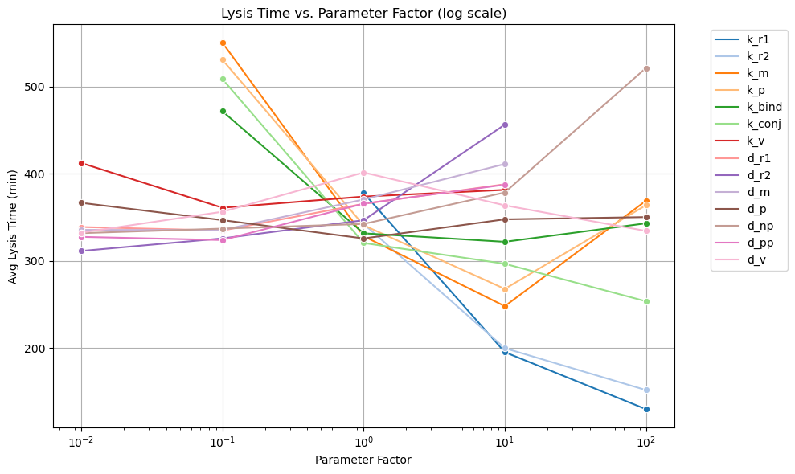

```python
import pandas as pd
import matplotlib.pyplot as plt
import seaborn as sns

# Load the averaged parameter testing results
new_df = pd.read_csv("param_testing_results/param_testing_averaged.csv")

palette = sns.color_palette("tab20", n_colors=20)

# Clean non-numeric values from lysis time and first virion columns
new_df["Avg Lysis Time (min)"] = pd.to_numeric(new_df["Avg Lysis Time (min)"], errors="coerce")
new_df["Avg Time to First Virion (min)"] = pd.to_numeric(new_df["Avg Time to First Virion (min)"], errors="coerce")
new_df["Factor"] = pd.to_numeric(new_df["Factor"], errors="coerce")

# --- Plot 1: Avg Lysis Time ---
plt.figure(figsize=(10, 6))
sns.lineplot(data=new_df, x="Factor", y="Avg Lysis Time (min)", hue="Reaction Rate Key", marker="o", palette = palette)
plt.xscale("log")
plt.title("Lysis Time vs. Parameter Factor (log scale)")
plt.xlabel("Parameter Factor")
plt.ylabel("Avg Lysis Time (min)")
plt.grid(True)
plt.legend(bbox_to_anchor=(1.05, 1), loc='upper left')
plt.tight_layout()
plt.show()
```

***Figure 6: Lineplot of Lysis Time vs Parameter Factor***

In figure 6, we see how particular parameters behave similarly, and it will be helpful to break down the line plot to explore how different groups of reaction rates influence lysis time, offering a clearer view of their individual effects on the simulation. The parameters have been broken into four separate groups based on their respective behaviors.

# **Lysis Time vs Parameter Factor, Group 1**

```python
import pandas as pd
import matplotlib.pyplot as plt
import seaborn as sns

# Load and clean data
new_df = pd.read_csv("param_testing_results/param_testing_averaged.csv")
new_df["Avg Lysis Time (min)"] = pd.to_numeric(new_df["Avg Lysis Time (min)"], errors="coerce")
new_df["Factor"] = pd.to_numeric(new_df["Factor"], errors="coerce")

# Consistent tab20 palette across all plots
reaction_keys = new_df["Reaction Rate Key"].unique()
palette = sns.color_palette("tab20", n_colors=20)
color_dict = dict(zip(reaction_keys, palette))

# Y-axis range
ymin, ymax = 100, 600
```

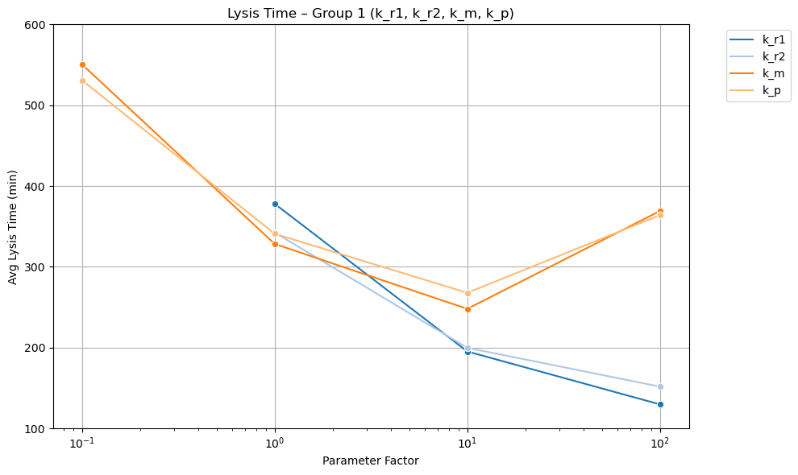

```python
group1 = ["k_r1", "k_r2", "k_m", "k_p"]

plt.figure(figsize=(10, 6))
sns.lineplot(data=new_df[new_df["Reaction Rate Key"].isin(group1)],
             x="Factor", y="Avg Lysis Time (min)",
             hue="Reaction Rate Key", marker="o", palette=color_dict)
plt.xscale("log")
plt.ylim(ymin, ymax)
plt.title("Lysis Time – Group 1 (k_r1, k_r2, k_m, k_p)")
plt.xlabel("Parameter Factor")
plt.ylabel("Avg Lysis Time (min)")
plt.grid(True)
plt.legend(bbox_to_anchor=(1.05, 1), loc='upper left')
plt.tight_layout()
plt.show()
```

***Figure 7: Lineplot of Lysis Time vs Parameter Factor, Group 1***

The figure above shows the average lysis time for Group 1 reaction rates — including the production of plus-RNA, minus-RNA, mRNA, and proteins — across different parameter magnitudes. For RNA strand production, we see no lysis when the magnitudes are low, but lysis time drops sharply as the rates increase. In contrast, the production of mRNA and proteins shows a different pattern: lysis time decreases at first, then rises again at higher magnitudes. This suggests a non-linear relationship, where overly high transcription and translation rates may reduce the system's efficiency, slowing virion production and delaying lysis.

# **Lysis Time vs Parameter Factor, Group 2**

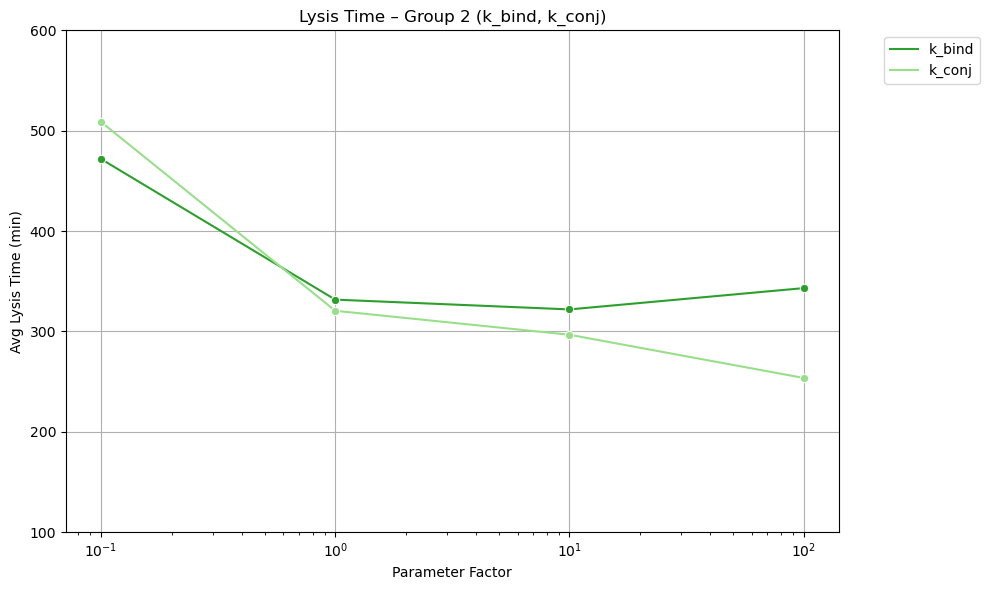

```python
group2 = ["k_bind", "k_conj"]

plt.figure(figsize=(10, 6))
sns.lineplot(data=new_df[new_df["Reaction Rate Key"].isin(group2)],
             x="Factor", y="Avg Lysis Time (min)",
             hue="Reaction Rate Key", marker="o", palette=color_dict)
plt.xscale("log")
plt.ylim(ymin, ymax)
plt.title("Lysis Time – Group 2 (k_bind, k_conj)")
plt.xlabel("Parameter Factor")
plt.ylabel("Avg Lysis Time (min)")
plt.grid(True)
plt.legend(bbox_to_anchor=(1.05, 1), loc='upper left')
plt.tight_layout()
plt.show()
```

***Figure 8: Lineplot of Lysis Time vs Parameter Factor, Group 2***

In the above figure, we see the average lysis time for Group 2 reaction rates (production of minus-RNP and plus-RNP) across different parameter factors. Both reactions show similar trends, where lysis time decreases initially as the parameter factor increases, but then levels off or varies slightly at higher magnitudes. This suggests that for certain factors, increasing the reaction rates initially accelerates the viral replication process, leading to faster lysis, but beyond a certain threshold, further increases may have diminishing returns.

# **Lysis Time vs Parameter Factor, Group 3**

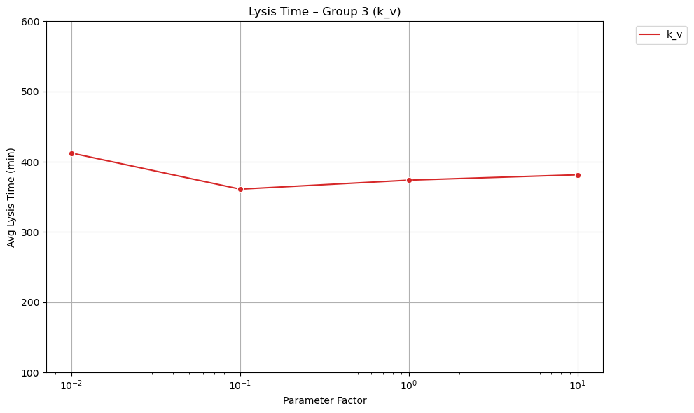

```python
group3 = [ "k_v"]

plt.figure(figsize=(10, 6))
sns.lineplot(data=new_df[new_df["Reaction Rate Key"].isin(group3)],
             x="Factor", y="Avg Lysis Time (min)",
             hue="Reaction Rate Key", marker="o", palette=color_dict)
plt.xscale("log")
plt.ylim(ymin, ymax)
plt.title("Lysis Time – Group 3 (k_v)")
plt.xlabel("Parameter Factor")
plt.ylabel("Avg Lysis Time (min)")
plt.grid(True)
plt.legend(bbox_to_anchor=(1.05, 1), loc='upper left')
plt.tight_layout()
plt.show()
```

***Figure 9: Lineplot of Lysis Time vs Parameter Factor, Group 3***

In Group 3 (production of virions), we observe that lysis time remains relatively constant across the different parameter factors, hovering around 400 minutes. This was somewhat unexpected — we would typically anticipate that increasing the virion production rate would lead to earlier lysis, as virions would accumulate more quickly. The lack of variation in lysis time suggests that virion production may not be the bottleneck in this system; rather, upstream processes like RNA replication or protein synthesis could be the rate-limiting steps. In other words, even when the virion production rate increases, it may not impact lysis timing unless those earlier steps also accelerate.

# **Lysis Time vs Parameter Factor, Group 4**

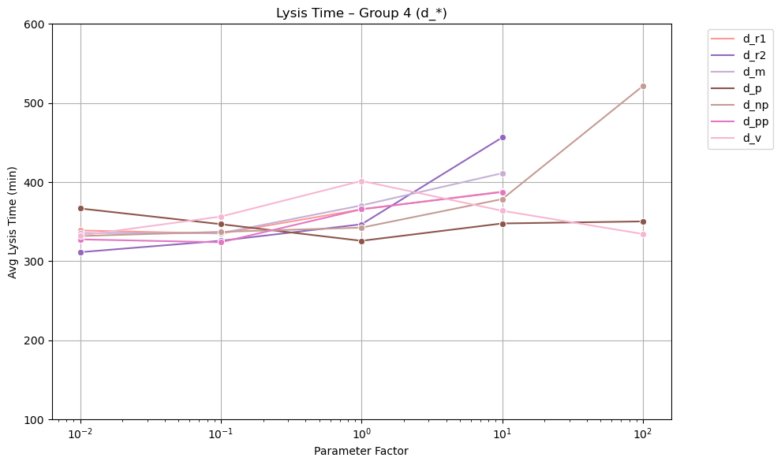

```python
group4 = ["d_r1", "d_r2", "d_m", "d_p", "d_np", "d_pp", "d_v"]

plt.figure(figsize=(10, 6))
sns.lineplot(data=new_df[new_df["Reaction Rate Key"].isin(group4)],
             x="Factor", y="Avg Lysis Time (min)",
             hue="Reaction Rate Key", marker="o", palette=color_dict)
plt.xscale("log")
plt.ylim(ymin, ymax)
plt.title("Lysis Time – Group 4 (d_*)")
plt.xlabel("Parameter Factor")
plt.ylabel("Avg Lysis Time (min)")
plt.grid(True)
plt.legend(bbox_to_anchor=(1.05, 1), loc='upper left')
plt.tight_layout()
plt.show()
```

***Figure 10: Lineplot of Lysis Time vs Parameter Factor, Group 4***

In Group 4 (degradation rates: minus-RNA, plus-RNA, mRNA, proteins, minus-RNP, plus-RNP, and virions), we see that lysis time remains relatively low and stable across different parameter factors. At higher magnitudes of degradation rates, lysis time disappears, indicating that the viral load never reaches the threshold required for lysis. This likely happens because increased degradation rates lead to faster loss of viral molecules, preventing the accumulation of virions to the necessary level for cell lysis to occur. Therefore, the cell never reaches the virion threshold, and thus, no lysis is observed.

### **Conclusion for Lysis Time Analysis – 4 Groups of Parameters**

The analysis of the four parameter groups reveals that plus-RNA and minus-RNA production have the most significant impact on lysis time, reducing it substantially at higher magnitudes. In contrast, degradation parameters (Group 4) show an adverse effect, with some causing no lysis at all due to high degradation rates. Overall, the findings suggest that replication-related parameters are the key drivers decreasing lysis time, while degradation rates prevent virion accumulation at higher levels, increasing lysis time or preventing lysis altogether.

# **Virion Production vs. Parameter Factors**

By examining the relationship between various reaction rates and average virion production, we can explore how changes in these rates affect the final output of virions during the simulation. This analysis will help us identify which reaction rates are most influential in driving virion production and how different magnitudes of these parameters contribute to the overall efficiency of the viral replication process.

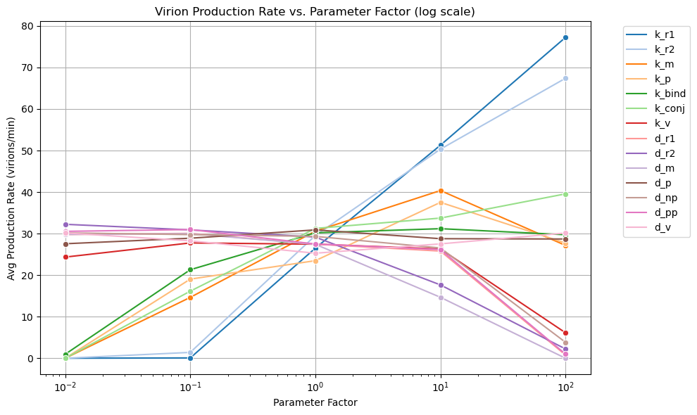

```python
palette = sns.color_palette("tab20", n_colors=20)

plt.figure(figsize=(10, 6))
sns.lineplot(data=new_df, x="Factor", y="Avg Production Rate (per min)", hue="Reaction Rate Key", marker="o", palette = palette)
plt.xscale("log")
plt.title("Virion Production Rate vs. Parameter Factor (log scale)")
plt.xlabel("Parameter Factor")
plt.ylabel("Avg Production Rate (virions/min)")
plt.grid(True)
plt.legend(bbox_to_anchor=(1.05, 1), loc='upper left')
plt.tight_layout()
plt.show()
```

***Figure 11: Lineplot of Virion Production Rate vs Parameter Factor***

In Figure 11, we can observe the behavior of different parameters in terms of their impact on virion production. Similar to the analysis of lysis time, we can break down the line plot to examine how different groups of reaction rates—categorized by their respective trends—affect virion production.

# **Virion Production vs. Parameter Factors, Group 1**

```python
import pandas as pd
import matplotlib.pyplot as plt
import seaborn as sns

# Load and clean data
new_df = pd.read_csv("param_testing_results/param_testing_averaged.csv")
new_df["Avg Production Rate (per min)"] = pd.to_numeric(new_df["Avg Production Rate (per min)"], errors="coerce")
new_df["Factor"] = pd.to_numeric(new_df["Factor"], errors="coerce")

# Define consistent color palette using tab20
all_keys = new_df["Reaction Rate Key"].unique()
palette_colors = sns.color_palette("tab20", n_colors=len(all_keys))
color_dict = dict(zip(all_keys, palette_colors))

# Axis limits
ymin = 0
ymax = 80
```

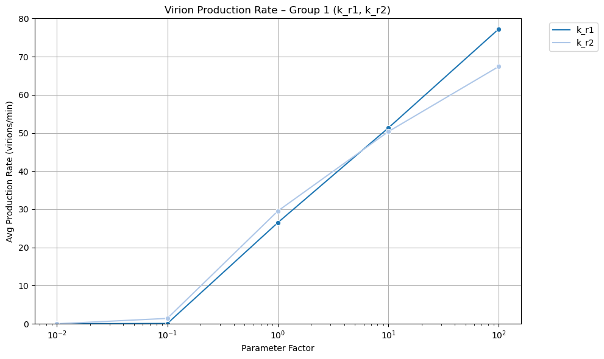

```python
group1 = ["k_r1", "k_r2"]

plt.figure(figsize=(10, 6))
sns.lineplot(data=new_df[new_df["Reaction Rate Key"].isin(group1)],
             x="Factor", y="Avg Production Rate (per min)",
             hue="Reaction Rate Key", palette=color_dict, marker="o")
plt.xscale("log")
plt.ylim(ymin, ymax)
plt.title("Virion Production Rate – Group 1 (k_r1, k_r2)")
plt.xlabel("Parameter Factor")
plt.ylabel("Avg Production Rate (virions/min)")
plt.grid(True)
plt.legend(bbox_to_anchor=(1.05, 1), loc='upper left')
plt.tight_layout()
plt.show()
```

***Figure 12: Lineplot of Virion Production Rate vs Parameter Factor, Group 1***

In Figure 12, we observe a clear and steady increase in the average virion production rate as the parameter factors for plus-RNA and minus-RNA production rise. Both reaction rates show similar behavior, with virion production increasing as the magnitudes of these parameters increase, which is expected as higher values of replication-related reaction rates result in faster virion generation. This indicates a strong dependency of virion production on these specific reaction rates.

# **Virion Production vs. Parameter Factors, Group 2**

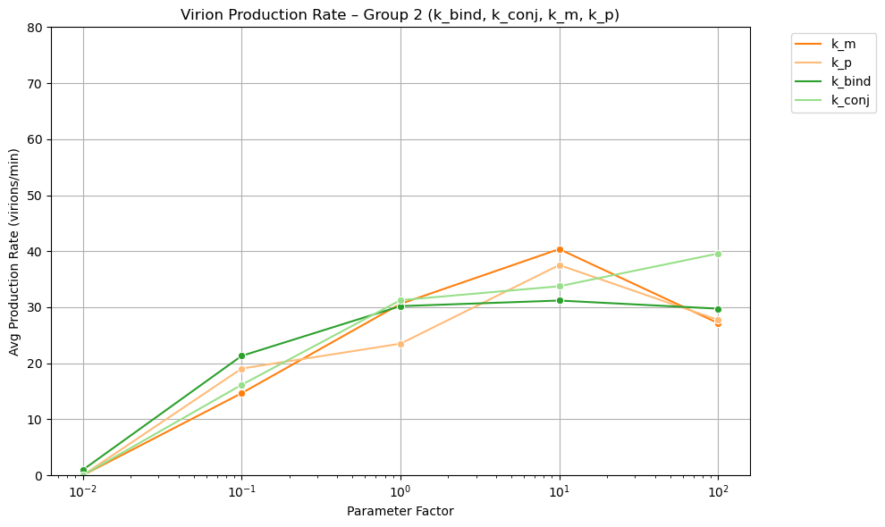

```python
group2 = ["k_bind", "k_conj", "k_m", "k_p"]

plt.figure(figsize=(10, 6))
sns.lineplot(data=new_df[new_df["Reaction Rate Key"].isin(group2)],
             x="Factor", y="Avg Production Rate (per min)",
             hue="Reaction Rate Key", palette=color_dict, marker="o")
plt.xscale("log")
plt.ylim(ymin, ymax)
plt.title("Virion Production Rate – Group 2 (k_bind, k_conj, k_m, k_p)")
plt.xlabel("Parameter Factor")
plt.ylabel("Avg Production Rate (virions/min)")
plt.grid(True)
plt.legend(bbox_to_anchor=(1.05, 1), loc='upper left')
plt.tight_layout()
plt.show()
```

***Figure 13: Lineplot of Virion Production Rate vs Parameter Factor, Group 2***

# **Virion Production vs. Parameter Factors, Group 3**

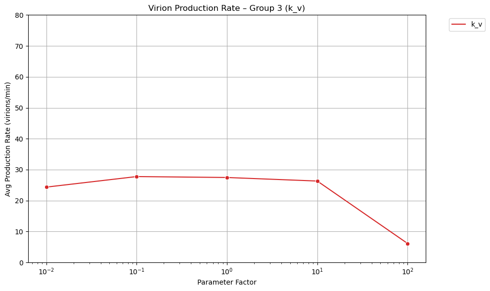

```python
group3 = ["k_v"]

plt.figure(figsize=(10, 6))
sns.lineplot(data=new_df[new_df["Reaction Rate Key"].isin(group3)],
             x="Factor", y="Avg Production Rate (per min)",
             hue="Reaction Rate Key", palette=color_dict, marker="o")
plt.xscale("log")
plt.ylim(ymin, ymax)
plt.title("Virion Production Rate – Group 3 (k_v)")
plt.xlabel("Parameter Factor")
plt.ylabel("Avg Production Rate (virions/min)")
plt.grid(True)
plt.legend(bbox_to_anchor=(1.05, 1), loc='upper left')
plt.tight_layout()
plt.show()
```

***Figure 14: Lineplot of Virion Production Rate vs Parameter Factor, Group 3***

The virion production rate for virion production remained steady across different magnitudes until the largest magnitude, where a significant drop occurred. This was unexpected — as the reaction rate responsible for virion production increases, we would typically expect to see an increase in virion production. However, this did not happen, suggesting this behavior could be an interesting avenue for further investigation.

# **Virion Production vs. Parameter Factors, Group 4**

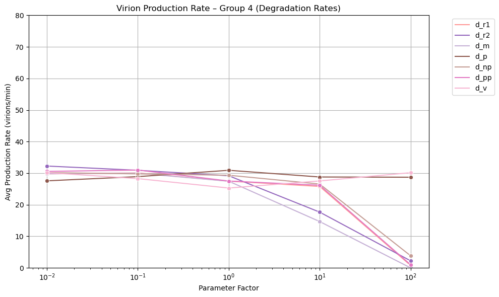

```python
group4 = ["d_r1", "d_r2", "d_m", "d_p", "d_np", "d_pp", "d_v"]

plt.figure(figsize=(10, 6))
sns.lineplot(data=new_df[new_df["Reaction Rate Key"].isin(group4)],
             x="Factor", y="Avg Production Rate (per min)",
             hue="Reaction Rate Key", palette=color_dict, marker="o")
plt.xscale("log")
plt.ylim(ymin, ymax)
plt.title("Virion Production Rate – Group 4 (Degradation Rates)")
plt.xlabel("Parameter Factor")
plt.ylabel("Avg Production Rate (virions/min)")
plt.grid(True)
plt.legend(bbox_to_anchor=(1.05, 1), loc='upper left')
plt.tight_layout()
plt.show()
```

***Figure 15: Lineplot of Virion Production Rate vs Parameter Factor, Group 4***

In Figure 15, we observe that minus-RNA, plus-RNA, mRNA, and minus-RNP degradation show a noticeable decline in virion production rate as the degradation rate magnitude increases. This behavior is expected, as higher degradation rates would typically lead to a decrease in the number of available virions, resulting in lower overall production. The trends seen in these degradation rates align with our expectations that increased degradation slows down virion production.

### **Conclusion for Virion Production Analysis – 4 Groups of Parameters**

The analysis of the four parameter groups indicates that plus-RNA and minus-RNA production have a strong positive correlation with virion production — as their rates increase, virion production also rises. In contrast, parameters like minus-RNA, plus-RNA, mRNA, and minus-RNP degradation exhibit a decline in virion production at higher magnitudes, aligning with expectations that increased degradation rates lead to lower production. Overall, the findings highlight that replication-related parameters drive higher virion production, while degradation rates significantly limit production as they increase.

# **Time to First Virion vs. Parameter Factors**

By analyzing the time to first virion in relation to different reaction rates, we can gain insights into how these parameters influence the speed at which the viral replication process begins. This analysis will help identify which reaction rates have the most significant impact on the timing of the initial virion production, shedding light on how variations in parameter magnitudes can accelerate or delay the onset of viral replication in the simulation.

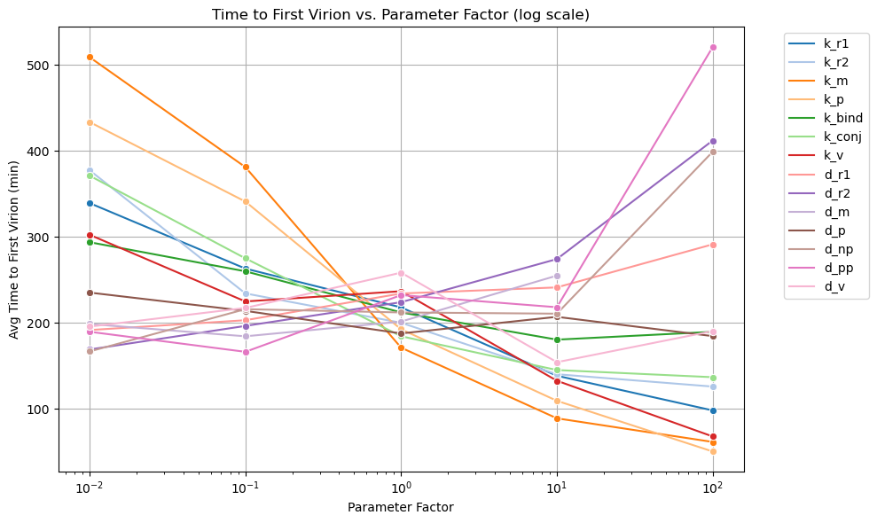

```python
new_df["Avg Time to First Virion (min)"] = pd.to_numeric(new_df["Avg Time to First Virion (min)"], errors="coerce")
new_df["Factor"] = pd.to_numeric(new_df["Factor"], errors="coerce")

# Reset palette mapping
reaction_keys = new_df["Reaction Rate Key"].unique()
palette = sns.color_palette("tab20", n_colors=20)
color_dict = dict(zip(reaction_keys, palette))
plt.figure(figsize=(10, 6))
sns.lineplot(
    data=new_df,
    x="Factor",
    y="Avg Time to First Virion (min)",
    hue="Reaction Rate Key",
    marker="o",
    palette=color_dict
)
plt.xscale("log")
plt.title("Time to First Virion vs. Parameter Factor (log scale)")
plt.xlabel("Parameter Factor")
plt.ylabel("Avg Time to First Virion (min)")
plt.grid(True)
plt.legend(bbox_to_anchor=(1.05, 1), loc='upper left')
plt.tight_layout()
plt.show()
```

***Figure 16: Lineplot of Time to First Virion vs Parameter Factor***

In figure 16, we can observe the behavior of different parameters in terms of their impact on the time to first virion. Similar to the analysis of virion production, we can break down the line plot to examine how different groups of reaction rates—categorized by their respective trends—affect the time taken for the first virion to be produced in the simulation.

# **Time to First Virion vs. Parameter Factors, Group 1**

```python
import pandas as pd
import matplotlib.pyplot as plt
import seaborn as sns

# Load and clean
new_df = pd.read_csv("param_testing_results/param_testing_averaged.csv")
new_df["Avg Time to First Virion (min)"] = pd.to_numeric(new_df["Avg Time to First Virion (min)"], errors="coerce")
new_df["Factor"] = pd.to_numeric(new_df["Factor"], errors="coerce")

# Define consistent tab20 color mapping
reaction_keys = new_df["Reaction Rate Key"].unique()
palette = sns.color_palette("tab20", n_colors=20)
color_dict = dict(zip(reaction_keys, palette))

ymin, ymax = 0, 550
```

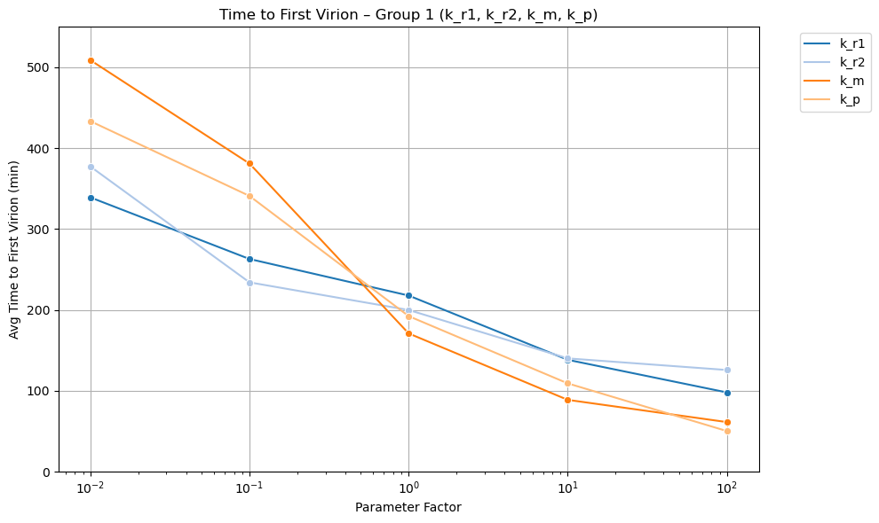

```python
group1 = ["k_r1", "k_r2", "k_m", "k_p"]

plt.figure(figsize=(10, 6))
sns.lineplot(data=new_df[new_df["Reaction Rate Key"].isin(group1)],
             x="Factor", y="Avg Time to First Virion (min)",
             hue="Reaction Rate Key", marker="o", palette=color_dict)
plt.xscale("log")
plt.ylim(ymin, ymax)
plt.title("Time to First Virion – Group 1 (k_r1, k_r2, k_m, k_p)")
plt.xlabel("Parameter Factor")
plt.ylabel("Avg Time to First Virion (min)")
plt.grid(True)
plt.legend(bbox_to_anchor=(1.05, 1), loc='upper left')
plt.tight_layout()
plt.show()
```

***Figure 17: Lineplot of Time to First Virion vs Parameter Factor, Group 1***

In Figure 17, as expected, increasing the reaction rates for plus-RNA, minus-RNA, mRNA, and protein production all result in sharp decreases in time to the first virion across all magnitudes. This behavior suggests that these parameters significantly influence the speed of viral replication, with higher magnitudes of these rates leading to faster viral replication initiation.

# **Time to First Virion vs. Parameter Factors, Group 2**

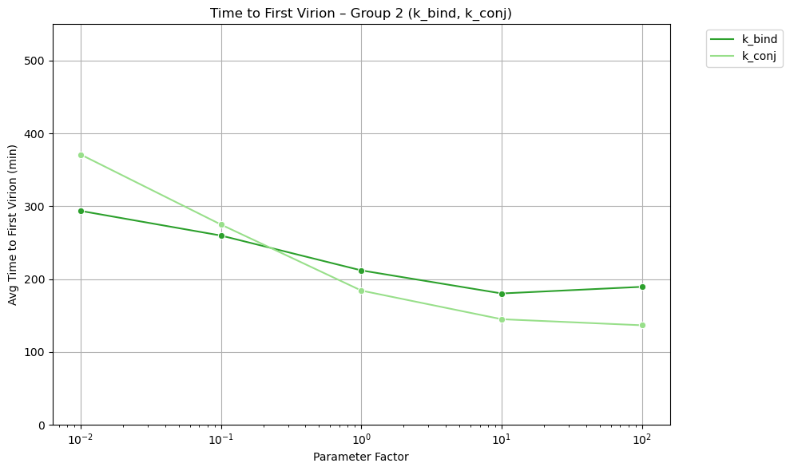

```python
group2 = ["k_bind", "k_conj"]

plt.figure(figsize=(10, 6))
sns.lineplot(data=new_df[new_df["Reaction Rate Key"].isin(group2)],
             x="Factor", y="Avg Time to First Virion (min)",
             hue="Reaction Rate Key", marker="o", palette=color_dict)
plt.xscale("log")
plt.ylim(ymin, ymax)
plt.title("Time to First Virion – Group 2 (k_bind, k_conj)")
plt.xlabel("Parameter Factor")
plt.ylabel("Avg Time to First Virion (min)")
plt.grid(True)
plt.legend(bbox_to_anchor=(1.05, 1), loc='upper left')
plt.tight_layout()
plt.show()
```

***Figure 18: Lineplot of Time to First Virion vs Parameter Factor, Group 2***

In Figure 18, the time to first virion for both minus-RNP and plus-RNP production decreases as their parameter factors increase, indicating that higher reaction rates lead to faster viral replication initiation. However, the decrease is more gradual compared to Group 1, and both lines level off at higher magnitudes. This suggests that once these parameters reach a certain threshold, their effect on the speed of replication diminishes, likely due to reaching an optimal rate of viral entry or binding.

# **Time to First Virion vs. Parameter Factors, Group 3**

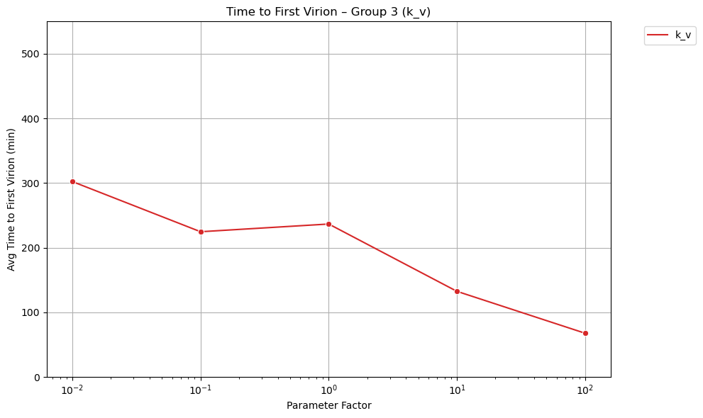

```python
group3 = ["k_v"]

plt.figure(figsize=(10, 6))
sns.lineplot(data=new_df[new_df["Reaction Rate Key"].isin(group3)],
             x="Factor", y="Avg Time to First Virion (min)",
             hue="Reaction Rate Key", marker="o", palette=color_dict)
plt.xscale("log")
plt.ylim(ymin, ymax)
plt.title("Time to First Virion – Group 3 (k_v)")
plt.xlabel("Parameter Factor")
plt.ylabel("Avg Time to First Virion (min)")
plt.grid(True)
plt.legend(bbox_to_anchor=(1.05, 1), loc='upper left')
plt.tight_layout()
plt.show()
```

***Figure 19: Lineplot of Time to First Virion vs Parameter Factor, Group 3***

The line plot shows a consistent decrease in the average time to the first virion as the virion production parameter factor increases, with the trend becoming more pronounced as the factor increases further (other than a rather stable change between 1.0e-01 and 1.0e+00). This suggests that increasing virion production accelerates the time to produce the first virion, which is consistent with the expected behavior of a reaction rate responsible for virion production. This steady decrease indicates that virion production plays a significant role in speeding up the viral replication process.

# **Time to First Virion vs. Parameter Factors, Group 4**

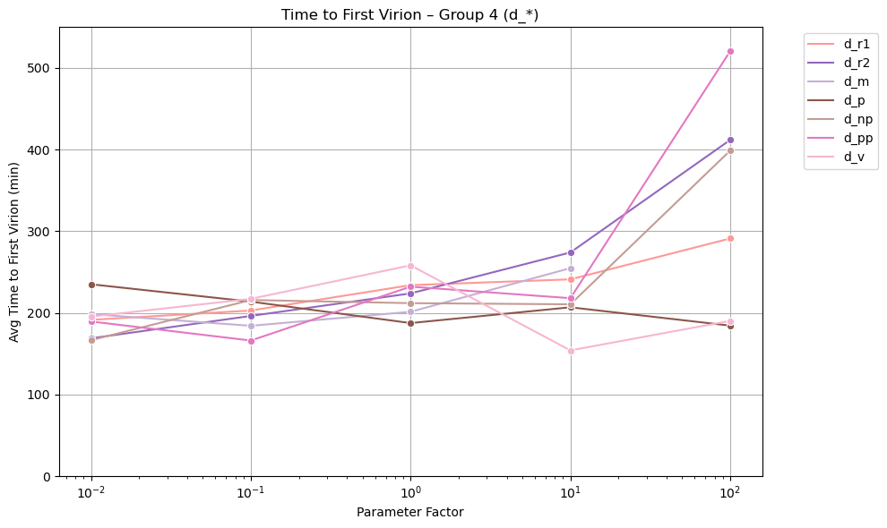

```python
group4 = ["d_r1", "d_r2", "d_m", "d_p", "d_np", "d_pp", "d_v"]

plt.figure(figsize=(10, 6))
sns.lineplot(data=new_df[new_df["Reaction Rate Key"].isin(group4)],
             x="Factor", y="Avg Time to First Virion (min)",
             hue="Reaction Rate Key", marker="o", palette=color_dict)
plt.xscale("log")
plt.ylim(ymin, ymax)
plt.title("Time to First Virion – Group 4 (d_*)")
plt.xlabel("Parameter Factor")
plt.ylabel("Avg Time to First Virion (min)")
plt.grid(True)
plt.legend(bbox_to_anchor=(1.05, 1), loc='upper left')
plt.tight_layout()
plt.show()
```

***Figure 20: Lineplot of Time to First Virion vs Parameter Factor, Group 4***

In Figure 20, while there is some variability across the degradation parameters, the overall trend remains relatively stable for most of them. However, we see significant increases in time to first virion for the degradation rates minus-RNA, plus-RNA, minus-RNP, and plus-RNP at higher magnitudes. This suggests that while most degradation rates have a minimal effect on the time to first virion, certain parameters — like minus-RNA and plus-RNA degradation — cause a notable delay in the production of the first virion as their magnitudes increase.

The analysis of the four parameter groups reveals that plus-RNA and minus-RNA production are strongly correlated with an increase in virion production as their values rise. For degradation parameters like minus-RNA, plus-RNA, mRNA, and minus-RNP degradation, the virion production generally remains steady at lower magnitudes, with no significant effect. However, at higher magnitudes, a notable decline in virion production is observed, as expected, due to increased degradation rates that limit virion accumulation.

# **A short statistical analysis...**

## **Spearman Correlation Between Metrics**

This analysis calculates the **Spearman correlation** between key metrics in the simulation, including **final virions**, **production rate**, **simulation time**, and **time to first virion**. Spearman correlation measures the strength and direction of the monotonic relationship between these variables, offering insights into how changes in one metric affect the others **[2]**. The heatmap visualizes these correlations, with values ranging from -1 to 1, where values closer to 1 or -1 indicate stronger positive or negative relationships, respectively. This method helps identify potential dependencies and patterns within the data, guiding further interpretation of the simulation results.

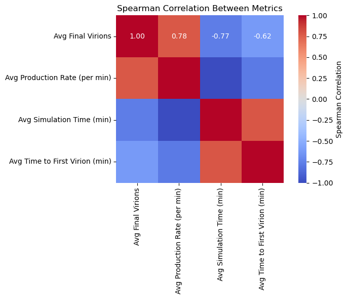

```python
import pandas as pd
import seaborn as sns
import matplotlib.pyplot as plt

# Load and prepare the data
df = pd.read_csv("param_testing_results/param_testing_averaged.csv")
df["Avg Final Virions"] = pd.to_numeric(df["Avg Final Virions"], errors="coerce")
df["Avg Production Rate (per min)"] = pd.to_numeric(df["Avg Production Rate (per min)"], errors="coerce")
df["Avg Simulation Time (min)"] = pd.to_numeric(df["Avg Simulation Time (min)"], errors="coerce")
df["Avg Time to First Virion (min)"] = pd.to_numeric(df["Avg Time to First Virion (min)"], errors="coerce")

# Compute correlation matrix
metrics = [
    "Avg Final Virions",
    "Avg Production Rate (per min)",
    "Avg Simulation Time (min)",
    "Avg Time to First Virion (min)"
]
corr = df[metrics].corr(method="spearman")

# Create heatmap with values shown
plt.figure(figsize=(8, 6))
sns.heatmap(corr, annot=True, fmt=".2f", cmap="coolwarm", vmin=-1, vmax=1, square=True, cbar_kws={"label": "Spearman Correlation"})
plt.title("Spearman Correlation Between Metrics")
plt.tight_layout()
plt.show()
```

***Figure 21: Spearman Correlation Heatmap***

## **Random Forest Feature Importance Analysis**

To gain deeper insights into the key factors that influence the likelihood of a simulated cell undergoing lysis, I utilized a **Random Forest Classifier**, a machine learning algorithm commonly used for binary classification tasks **[1]**.

**Inputs to the Model:**

- **Reaction Rate Identity:** Specifies which parameter (e.g., plus-RNA, virion degradation, etc.) was altered during the simulation.
- **Factor Value:** Represents the magnitude by which the parameter was adjusted.

**Output:**

- **Lysis Occurred:** A binary classification (1 for lysis, 0 for no lysis) that indicates whether the cell lysed during the simulation.

After training the model, I conducted a **feature importance analysis** to determine how the model prioritized each input variable when making predictions about lysis, providing valuable insights into which factors play a crucial role in the cell's fate.

```python
from sklearn.ensemble import RandomForestClassifier
from sklearn.preprocessing import LabelEncoder
from sklearn.model_selection import train_test_split

# STEP 1: Label the outcome
# Create a binary target: 1 = Lysis occurred, 0 = No lysis
df["Lysis Occurred"] = df["Avg Lysis Time (min)"].apply(lambda x: 0 if "No" in str(x) else 1)

# STEP 2: Convert reaction rate names to numbers (for model input)
label_encoder = LabelEncoder()
df["Rate Type (Encoded)"] = label_encoder.fit_transform(df["Reaction Rate Key"])

# STEP 3: Define input features and target
features = df[["Factor", "Rate Type (Encoded)"]]  # X
target = df["Lysis Occurred"]                     # y

# STEP 4: Split data into training and test sets
X_train, X_test, y_train, y_test = train_test_split(
    features, target, test_size=0.2, stratify=target, random_state=42
)

# STEP 5: Train a Random Forest model
model = RandomForestClassifier(n_estimators=100, random_state=42)
model.fit(X_train, y_train)

# STEP 6: Display feature importances
print("\n Feature Importance (How much each factor affects lysis prediction):")
for name, score in zip(features.columns, model.feature_importances_):
    print(f"- {name}: {score:.4f}")
```

```
 Feature Importance (How much each factor affects lysis prediction):
- Factor: 0.4427
- Rate Type (Encoded): 0.5573
```

In the Random Forest model, **feature importance** measures how much each input variable contributes to the model’s ability to make accurate predictions **[1]**. In this case:

**“Factor”** refers to the **magnitude of change** applied to the reaction rate during the simulation (e.g., 0.01x, 1x, 100x).

**“Rate Type”** refers to **which reaction rate was changed** (e.g., plus-RNA production, virion degradation, etc.).

### **Our Results:**

The feature importance values tell us how much each of these inputs influenced the model’s prediction of whether a simulation resulted in lysis:

A **44.27% importance for Factor** means the model used the **magnitude** of the change in the reaction rate almost half the time when deciding whether lysis occurred.

A **55.73% importance for Rate Type** means the **identity of the reaction rate being changed** was slightly more important than the size of the change.

**In plain terms:** The model decided that **what reaction you change** matters slightly more than **how much you change it** when predicting if a cell lyses.

# **Possible Future Changes**

To improve the reliability of the simulation results, **additional iterations** of each reaction rate and magnitude could be run. This would provide more data points, helping to refine the trends observed due to the stochastic nature of the simulation. **Further statistical analyses** could also be explored to capture more complex relationships between parameters.

Additionally, expanding the model to **account for superinfection** or simulating **multiple viruses** could add another layer of realism to the simulation. These enhancements would better reflect real-world viral interactions and their impact on lysis dynamics, potentially offering deeper insights into viral replication processes.

# **References**

[1] GeeksforGeeks. (2024, April 5). Feature importance with random forests. https://www.geeksforgeeks.org/feature-importance-with-random-forests/

[2] GeeksforGeeks. (2025, April 28). Spearman correlation Heatmap in R. https://www.geeksforgeeks.org/spearman-correlation-heatmap-in-r/

[3] Gillespie, D. (n.d.). Exact stochastic simulation of coupled chemical reactions | The Journal of Physical Chemistry. https://pubs.acs.org/doi/10.1021/j100540a008

[4] Heldt, F. S. (2015, November 20). Single-cell analysis and stochastic modelling unveil large cell-to-cell variability in influenza A virus infection. Nature News. https://www.nature.com/articles/ncomms9938

[5] Numba. (n.d.-a). A ~5 minute guide to numba. A ~5 minute guide to Numba - Numba 0.52.0.dev0+274.g626b40e-py3.7-linux-x86_64.egg documentation. https://numba.pydata.org/numba-doc/dev/user/5minguide.html

[6] Numba. (n.d.-b). Just-in-time compilation. Just-in-Time compilation - Numba 0.52.0.dev0+274.g626b40e-py3.7-linux-x86_64.egg documentation. https://numba.pydata.org/numba-doc/dev/reference/jit-compilation.html